# HDT2

Cruze de variables con el anio y mes

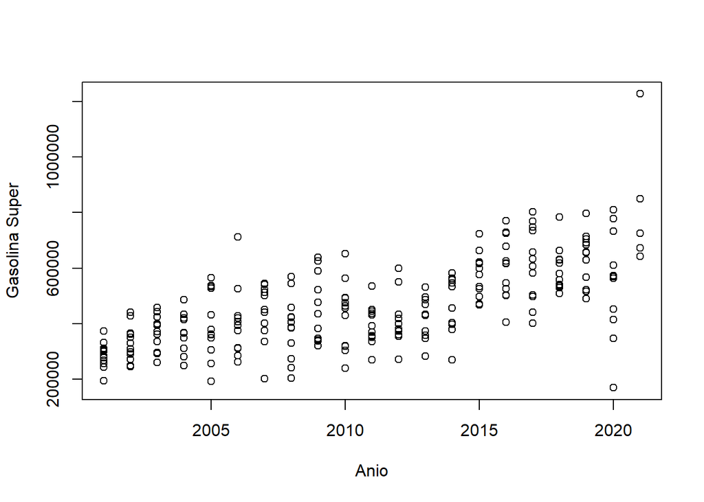

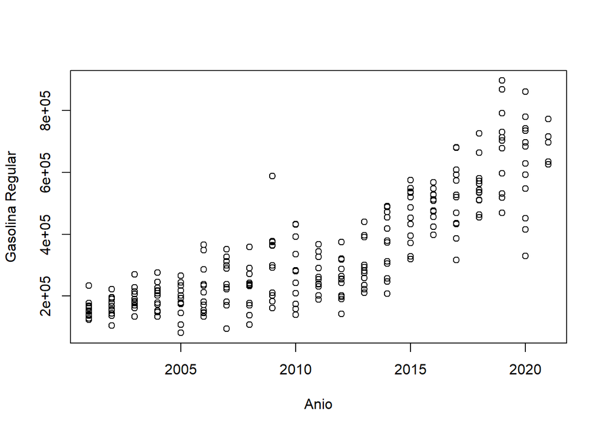

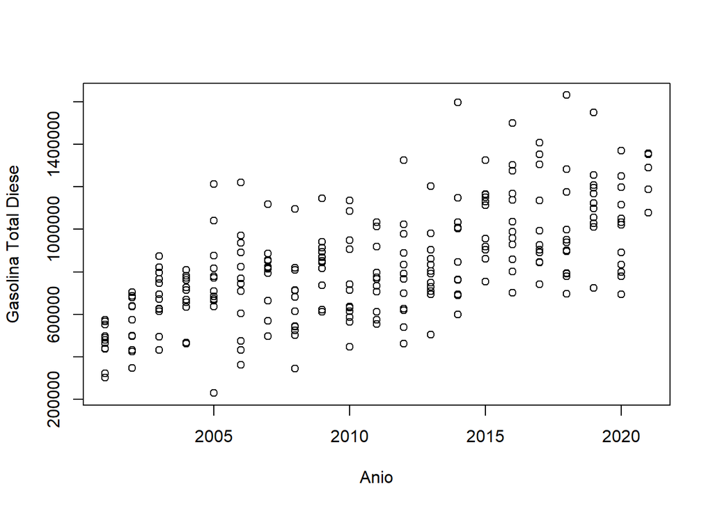

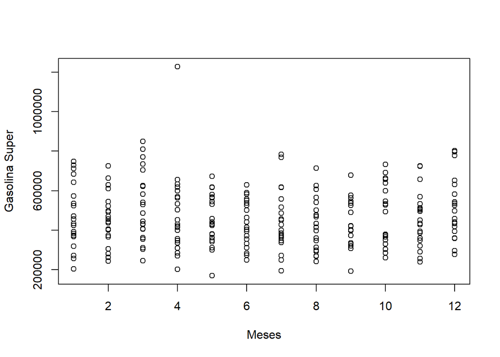

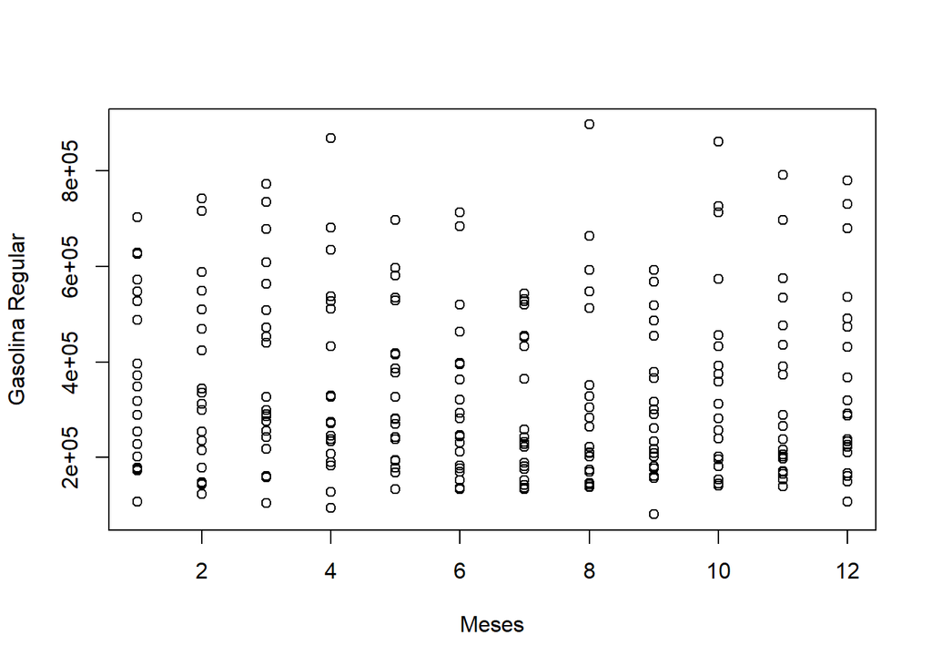

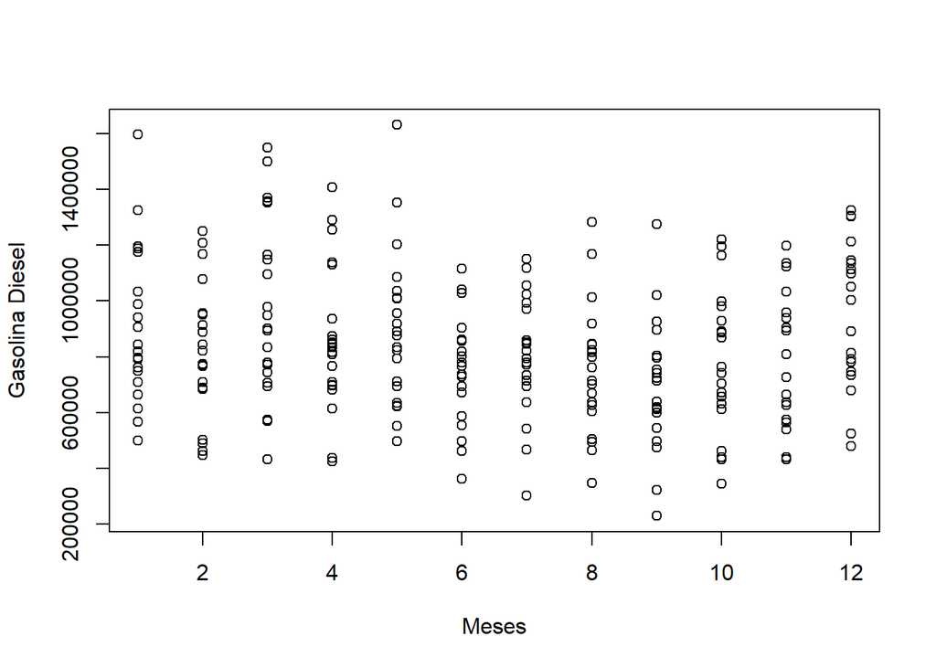

En las tres gráficas anteriores del cruce de variables de las importaciones de cualquier tipo de gasolina y el año, se puede observar que hay una tendencia a crecer. Esto implica que conforme pasa el tiempo, cada vez se importa más gasolina sin importar su tipo.

Por otro lado, al observar las gráficas del cruce de variables de cualquier tipo de gasolina con los meses, no se puede observar alguna tendencia. Esto implica que sin importar el mes, siempre va a haber una importación de combustible más o menos constante.

Para comenzar con el analisis de series de tiempo nos encontramos con la necesidad de unir la columna de mes y anio en una sola columna en formato de fecha, luego crear diferentes data frames para los 3 tipos de gasolinas para hacer una linea del tiempo de cada una.

```
## [1] 2000    1
```

```
## [1] 2021    5
```

```
## [1] 12
```

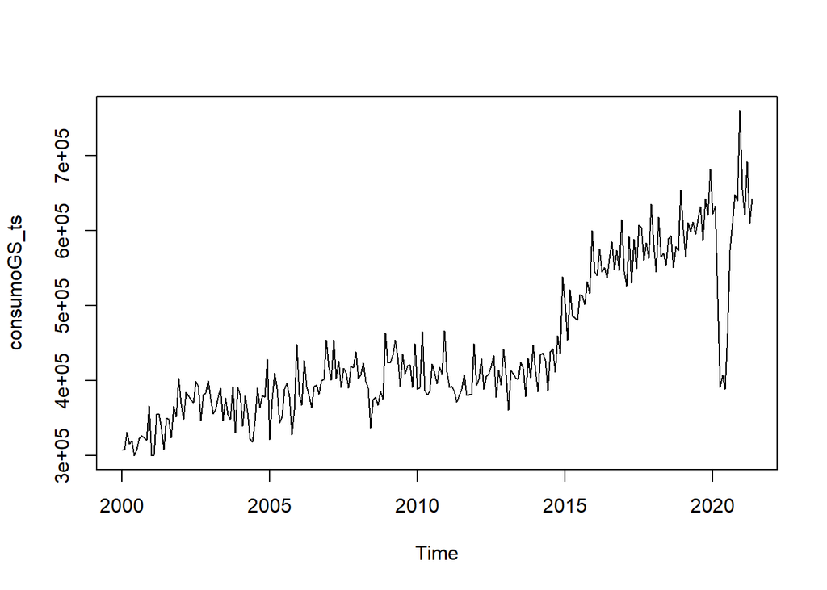

De esta linea podemos ver a primera vista que posee una tendencia a crecer, y que hay momentos en la linea de tiempo que hace que las varianzas tambien se vean afectadas y sean diferentes entre si. Podemos ver que se trata de una serie con frecuencia anual donde hay datos de todos los meses desde enero de 2000 hasta mayo del 2021.Como se puede ver la cantidad de galones vendidos va aumentando a medida que pasan los años.

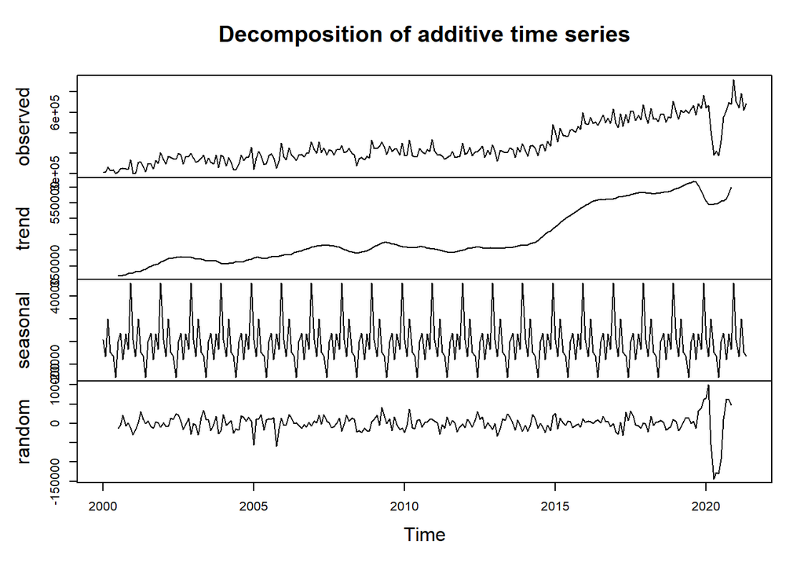

Podemos observar una serie con tendencia a aumentar, que no es estacionaria en varianza, y además tiene estacionalidad.

Ahora vemos los datos de inicio y fin del train y del test

```
## [1] 2000    1
```

```
## [1] 2014   12
```

```
## [1] 2015    1
```

```
## [1] 2021    5
```

Veremos si logramos estacionarizar la serie con esta transformación:

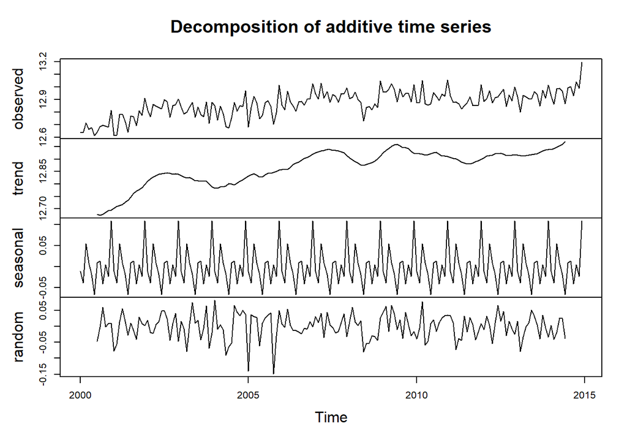

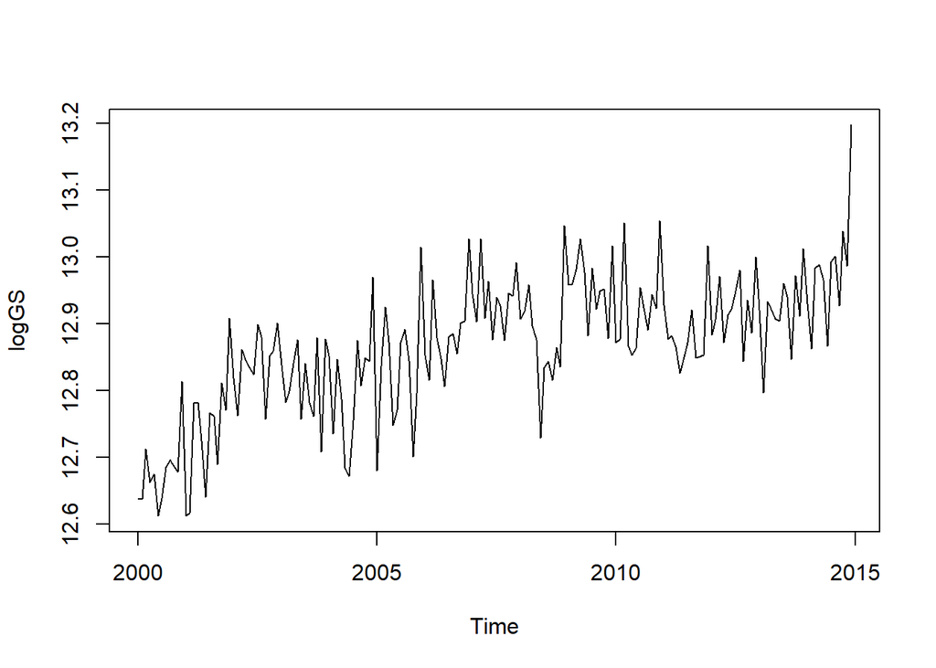

Podemos observar que las varianzas si se pudieron hacer mas constantes, sin embargo, se pueden observar picos de varianza desiguales, lo cual puede ser un problema y concreta que no se pudo estacionarizar en varianza en su totalidad.

Por lo que ahora trataremos de quitar la tendencia y estacionarizar en normalidad.

```
##
## Title:
##  Augmented Dickey-Fuller Test
##
## Test Results:
##   PARAMETER:
##     Lag Order: 1
##   STATISTIC:
##     Dickey-Fuller: 0.3673
##   P VALUE:
##     0.7319
##
## Description:
##  Fri Aug 06 20:29:52 2021 by user: LUIS PEDRO
```

```
##
## Title:
##  Augmented Dickey-Fuller Test
##
## Test Results:
##   PARAMETER:
##     Lag Order: 1
##   STATISTIC:
##     DF: 0.3673
##   P VALUE:
##     t: 0.7895
##     n: 0.773
##
## Description:
##  Fri Aug 06 20:29:52 2021 by user: LUIS PEDRO
```

Por lo que debemos de hacer lo mismo pero con una diferenciacion en la serie de tiempo.

```
##
## Title:
##  Augmented Dickey-Fuller Test
##
## Test Results:
##   PARAMETER:
##     Lag Order: 1
##   STATISTIC:
##     Dickey-Fuller: -17.2389
##   P VALUE:
##     0.01
##
## Description:
##  Fri Aug 06 20:29:52 2021 by user: LUIS PEDRO
```

Como se puede ver el valor de p ahora sí está por debajo de 0.05 por lo que se puede descartar la hipótesis nula de que existan raices unitarias.

Solo se hizo uso de una diferenciación, por lo que d es 1, pero para conocer p y q se debe de realizar un gráfico de autocorrelación y autocorrelación parcial.

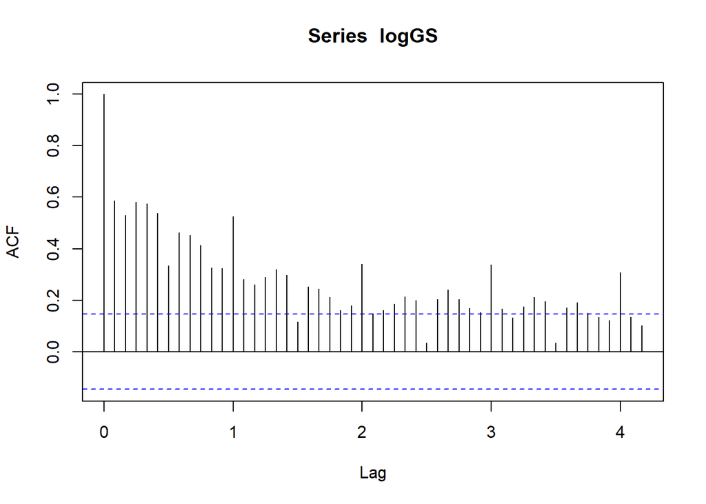

```r
acf(logGS,50)
```

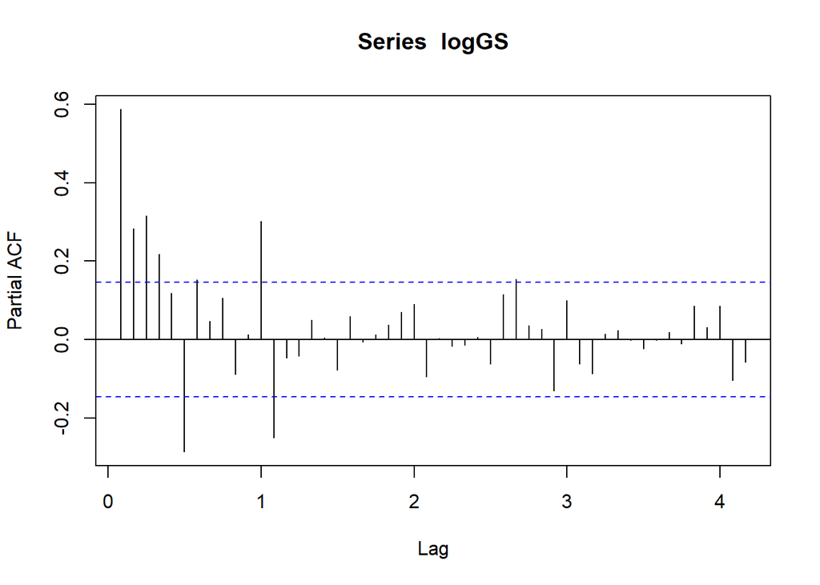

```r
pacf(logGS,50)
```

Por lo que podemos proponer un modelo ARIMA con p =4 q=1 d = 1

Veamos si hay estacionalidad en la serie. Si volvemos a ver la descomposición de la serie en su componente estacional.

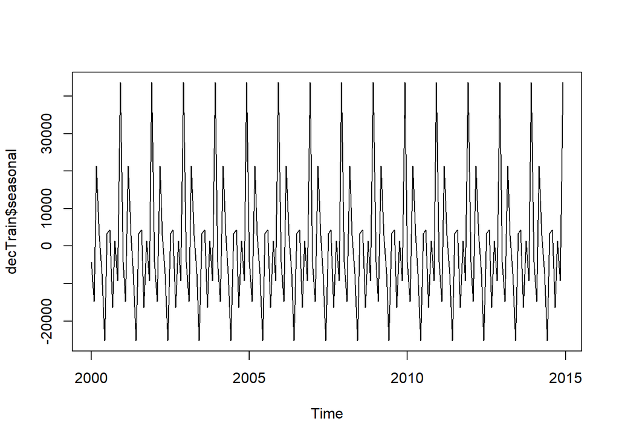

Al parecer sí existe estacionalidad en la serie. Para tener una idea de los parámetros estacionales veremos las funciones de autocorrelación y autocorrelación parcial con 36 resagos para ver en que momentos son los picos estacionales. Se usará la serie estacionarizada.

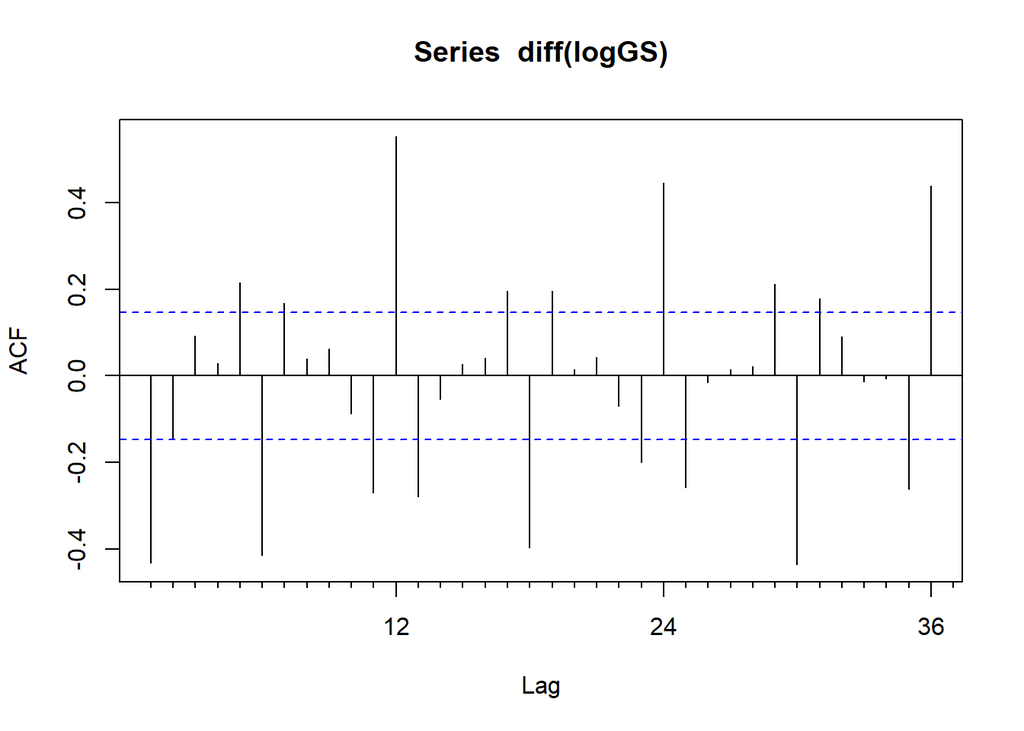

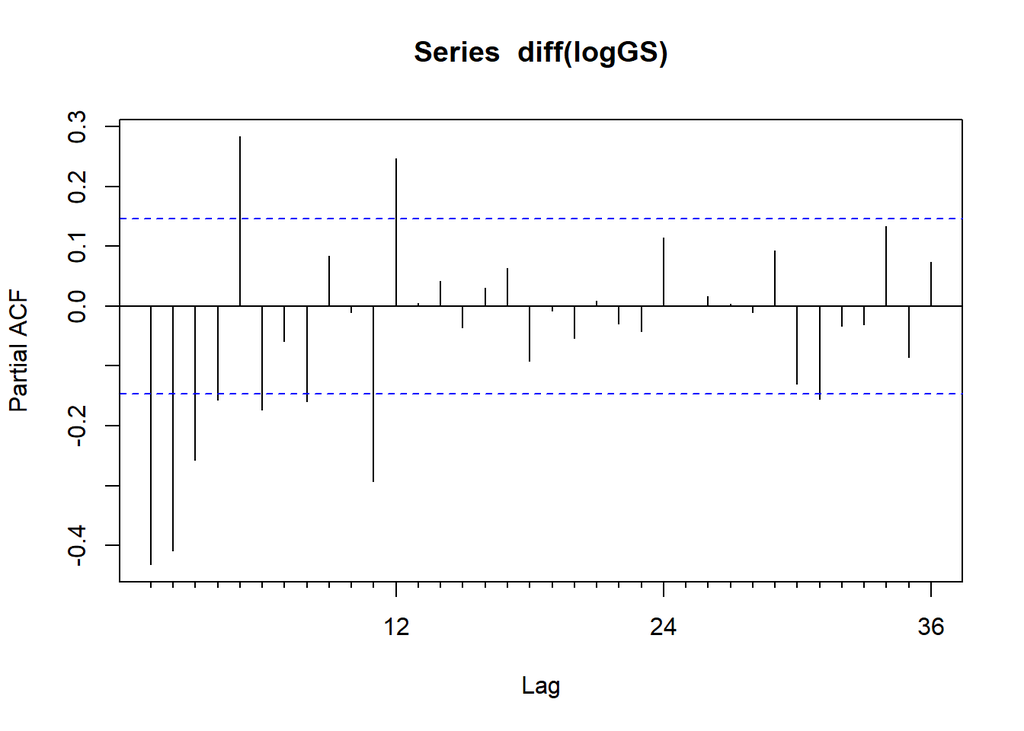

Creamos los analisis del modelo Hacemos un analisis de coeficientes del AutoArima y Arima.

```
##
## z test of coefficients:
##
##       Estimate Std. Error  z value  Pr(>|z|)
## ar1  -0.530999   0.255698  -2.0767 0.0378324 *
## ma1  -0.016694   0.240298  -0.0695 0.9446149
## ma2  -0.462657   0.139363  -3.3198 0.0009008 ***
## sar1 -0.021098   0.080054  -0.2635 0.7921275
## sar2 -0.137446   0.080886  -1.6993 0.0892688 .
## sma1 -0.999970   0.089828 -11.1321 < 2.2e-16 ***
## ---
## Signif. codes:  0 '***' 0.001 '**' 0.01 '*' 0.05 '.' 0.1 ' ' 1
```

```
##
## z test of coefficients:
##
##       Estimate Std. Error  z value  Pr(>|z|)
## ma1  -0.694455   0.061480 -11.2957 < 2.2e-16 ***
## sma1  0.403711   0.079137   5.1014 3.371e-07 ***
## sma2  0.218524   0.067869   3.2198  0.001283 **
## ---
## Signif. codes:  0 '***' 0.001 '**' 0.01 '*' 0.05 '.' 0.1 ' ' 1
```

Análisis de Residuales Los residuales deben ser lo más parecidos posible a un ruido blanco. Esto es que sean aleatorios (no están correlacionados entre sí), y que estén distribuidos normalmente. Analizamos los residuos de nuestro modelo fitArima

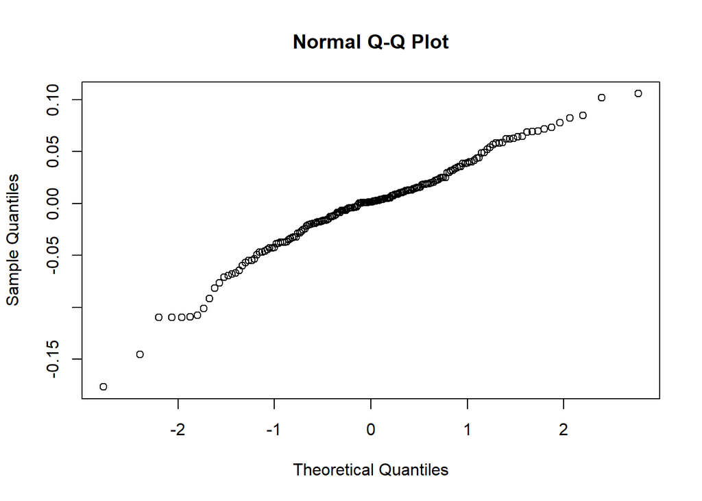

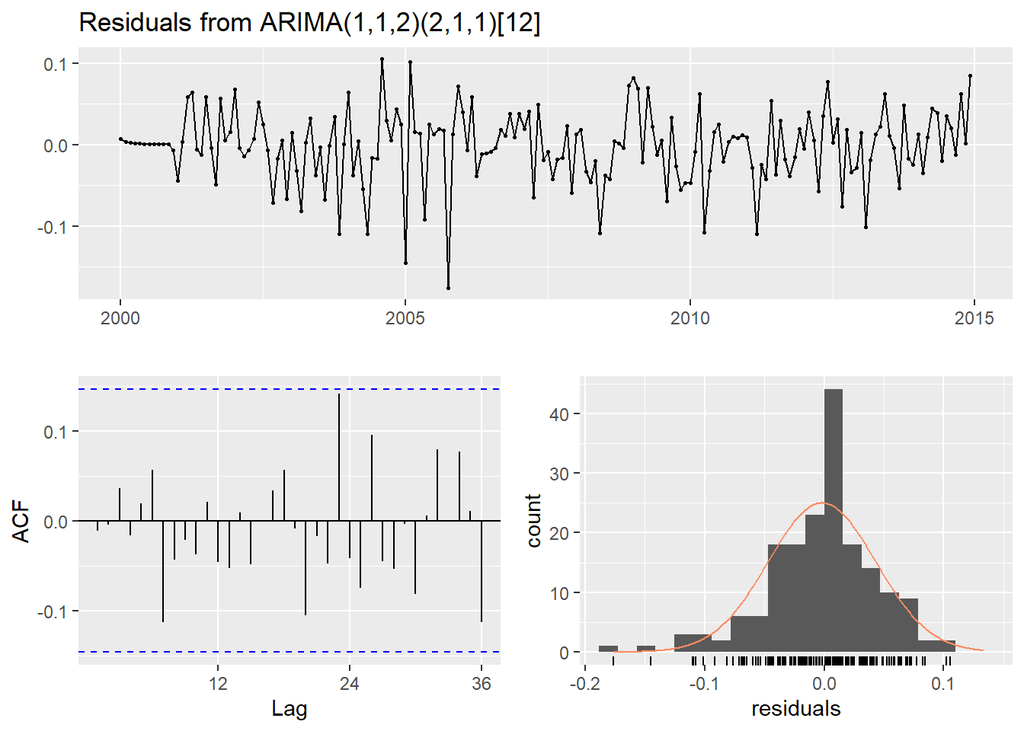

```
##
##  Ljung-Box test
##
## data:  Residuals from ARIMA(1,1,2)(2,1,1)[12]
## Q* = 13.882, df = 18, p-value = 0.7367
##
## Model df: 6.   Total lags used: 24
```

Según los gráficos podemos ver que la distribución de los datos parece ser normal, y que no hay correlaciones significativas. Según el test de Ljung-Box los datos se distribuyen de forma independiente puesto que el p-value es mayor a 0.05, por lo que no se puede rechazar la hipótesis nula. Esto significa que el modelo generado es aceptable para predecir.

Analizando los residuos del modelo generado de forma automática por R tenemos los siguientes resultados:

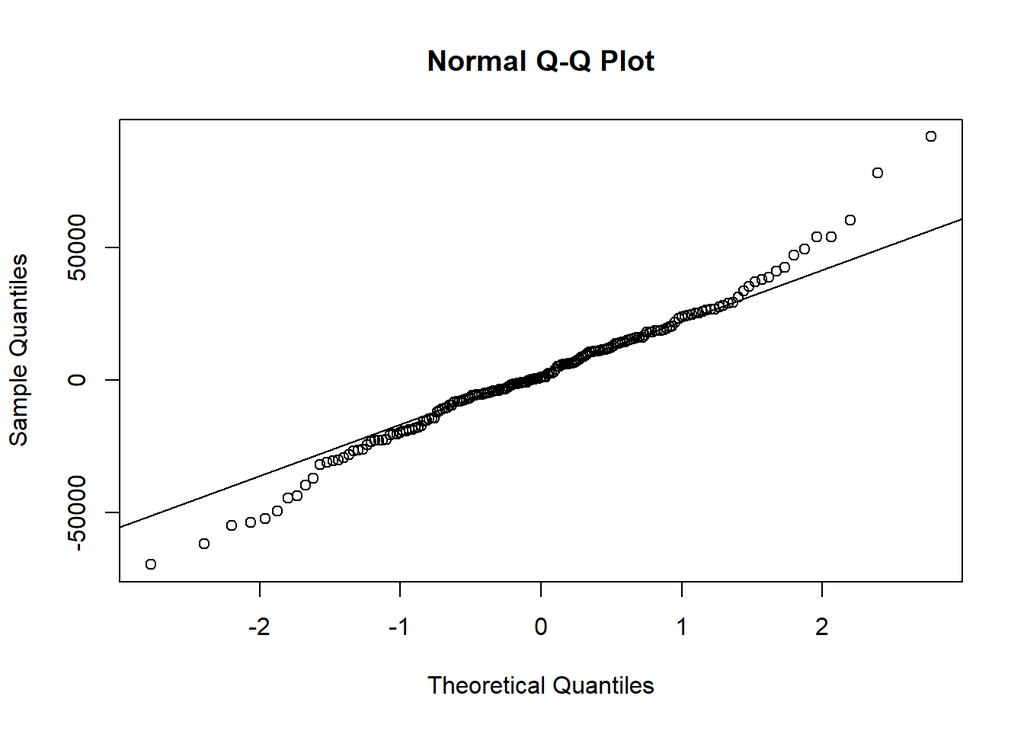

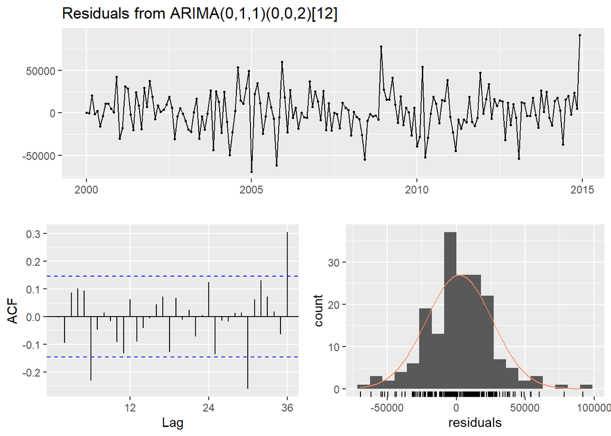

```
##
##  Ljung-Box test
##
## data:  Residuals from ARIMA(0,1,1)(0,0,2)[12]
## Q* = 35.203, df = 21, p-value = 0.02682
##
## Model df: 3.   Total lags used: 24
```

El modelo autogenerado no es un modelo aceptable para predecir.

```
##          Point Forecast    Lo 80    Hi 80    Lo 95    Hi 95
## Jan 2015       13.03072 12.96888 13.09256 12.93614 13.12530
## Feb 2015       13.00463 12.93677 13.07249 12.90085 13.10841
## Mar 2015       13.09947 13.02944 13.16950 12.99237 13.20658
## Apr 2015       13.04365 12.96995 13.11735 12.93094 13.15636
## May 2015       13.02189 12.94554 13.09824 12.90512 13.13866
## Jun 2015       12.97006 12.89072 13.04940 12.84872 13.09139
## Jul 2015       13.04983 12.96784 13.13183 12.92443 13.17523
## Aug 2015       13.05805 12.97337 13.14273 12.92854 13.18755
## Sep 2015       13.01030 12.92308 13.09752 12.87690 13.14370
## Oct 2015       13.04912 12.95939 13.13885 12.91189 13.18635
## Nov 2015       13.02783 12.93569 13.11997 12.88691 13.16875
## Dec 2015       13.16829 13.07378 13.26281 13.02374 13.31284
## Jan 2016       13.04320 12.94569 13.14071 12.89407 13.19233
## Feb 2016       13.02564 12.92563 13.12564 12.87270 13.17858
## Mar 2016       13.11409 13.01176 13.21642 12.95758 13.27059
## Apr 2016       13.06203 12.95736 13.16669 12.90196 13.22209
## May 2016       13.03888 12.93197 13.14579 12.87537 13.20239
## Jun 2016       13.00052 12.89139 13.10965 12.83362 13.16743
## Jul 2016       13.07097 12.95968 13.18227 12.90076 13.24119
## Aug 2016       13.07571 12.96229 13.18914 12.90224 13.24919
## Sep 2016       13.02441 12.90889 13.13992 12.84774 13.20107
## Oct 2016       13.06679 12.94922 13.18437 12.88698 13.24661
## Nov 2016       13.04360 12.92401 13.16318 12.86071 13.22648
## Dec 2016       13.17061 13.04903 13.29219 12.98468 13.35655
## Jan 2017       13.05617 12.93330 13.17904 12.86826 13.24408
## Feb 2017       13.03266 12.90822 13.15709 12.84235 13.22296
## Mar 2017       13.12479 12.99868 13.25089 12.93193 13.31764
## Apr 2017       13.08114 12.95346 13.20883 12.88586 13.27642
## May 2017       13.05784 12.92856 13.18712 12.86012 13.25556
## Jun 2017       13.01275 12.88191 13.14360 12.81265 13.21286
## Jul 2017       13.08970 12.95731 13.22210 12.88723 13.29218
## Aug 2017       13.09458 12.96065 13.22850 12.88976 13.29939
## Sep 2017       13.03977 12.90434 13.17521 12.83264 13.24690
## Oct 2017       13.09205 12.95512 13.22898 12.88263 13.30147
## Nov 2017       13.06462 12.92622 13.20303 12.85295 13.27630
## Dec 2017       13.20159 13.06171 13.34147 12.98766 13.41552
## Jan 2018       13.08123 12.93921 13.22324 12.86404 13.29842
## Feb 2018       13.05667 12.91300 13.20033 12.83695 13.27638
## Mar 2018       13.14960 13.00440 13.29479 12.92754 13.37166
```

[output cut: 23 more lines]

```
## Mar 2020       13.19776 13.01510 13.38041 12.91841 13.47710
## Apr 2020       13.15239 12.96821 13.33657 12.87071 13.43407
## May 2020       13.12928 12.94361 13.31495 12.84532 13.41323
## Jun 2020       13.08366 12.89650 13.27081 12.79742 13.36989
## Jul 2020       13.16069 12.97207 13.34932 12.87221 13.44918
## Aug 2020       13.16595 12.97586 13.35604 12.87523 13.45667
## Sep 2020       13.11209 12.92055 13.30363 12.81915 13.40502
## Oct 2020       13.16245 12.96946 13.35543 12.86731 13.45759
## Nov 2020       13.13589 12.94148 13.33029 12.83857 13.43320
## Dec 2020       13.27290 13.07706 13.46873 12.97339 13.57241
## Jan 2021       13.15220 12.95439 13.35001 12.84968 13.45472
## Feb 2021       13.12849 12.92914 13.32784 12.82361 13.43337
## Mar 2021       13.22087 13.02006 13.42168 12.91376 13.52798
## Apr 2021       13.17566 12.97337 13.37796 12.86628 13.48504
## May 2021       13.15255 12.94880 13.35629 12.84094 13.46415
```

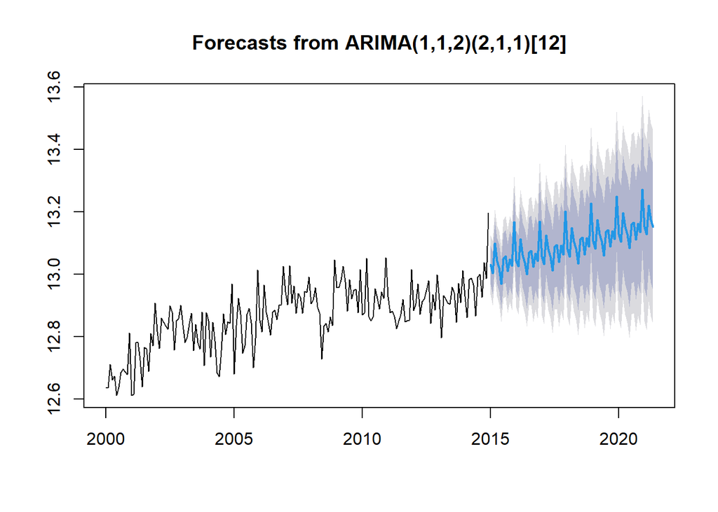

Como se puede ver, el modelo es bueno para predecir tendencias. Sin embargo, no se ve muy acertado para los datos que se tiene en el conjunto de test.

```
## Disabling daily seasonality. Run prophet with daily.seasonality=TRUE to override this.
```

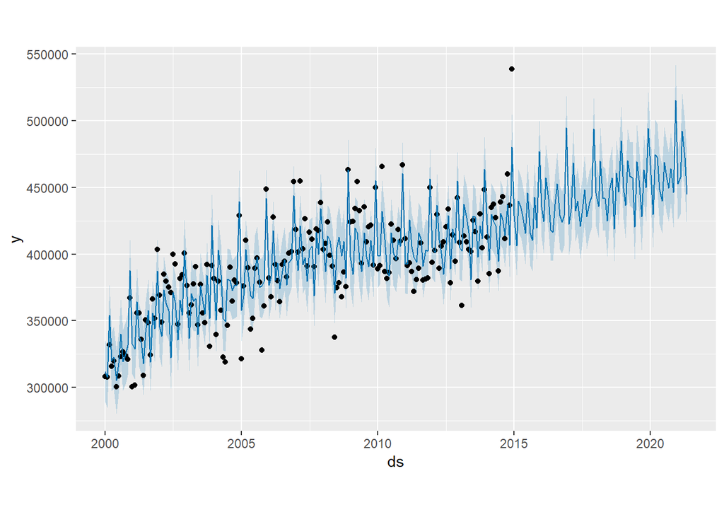

Veamos que tanto se acerca la predicción a los datos reales, en el siguiente gráfico. Los datos del conjunto de prueba se representan en rojo mientras los datos de la predicción se representan en azul.

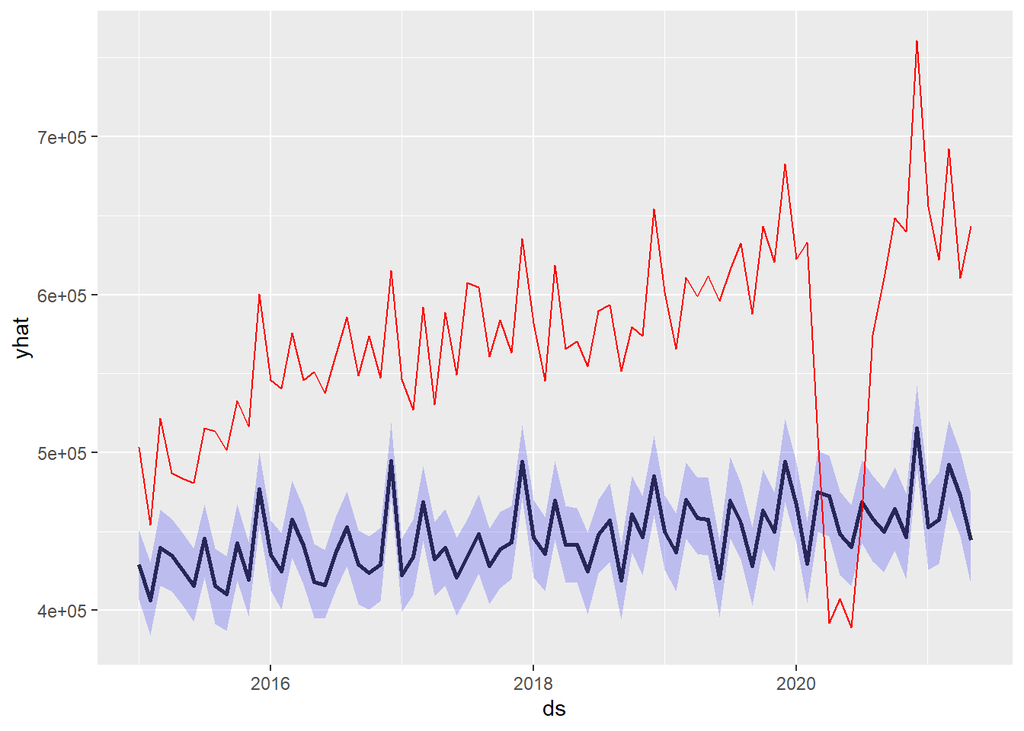

como podemos observar, las predicciones realizadas por prophet fueron peores y erroneas en comparacion con la funcion de Arima.

```r
train <- head(consumoGS_ts, round(length(consumoGS_ts) * 0.891632653))
h <- length(consumoGS_ts) - length(train)
test <- tail(consumoGS_ts, h)
end(train)
```

```
## [1] 2019    1
```

```r
fitArima %>%
  forecast(h)
```

```
##          Point Forecast    Lo 80    Hi 80    Lo 95    Hi 95
## Jan 2015       13.03072 12.96888 13.09256 12.93614 13.12530
## Feb 2015       13.00463 12.93677 13.07249 12.90085 13.10841
## Mar 2015       13.09947 13.02944 13.16950 12.99237 13.20658
## Apr 2015       13.04365 12.96995 13.11735 12.93094 13.15636
## May 2015       13.02189 12.94554 13.09824 12.90512 13.13866
## Jun 2015       12.97006 12.89072 13.04940 12.84872 13.09139
## Jul 2015       13.04983 12.96784 13.13183 12.92443 13.17523
## Aug 2015       13.05805 12.97337 13.14273 12.92854 13.18755
## Sep 2015       13.01030 12.92308 13.09752 12.87690 13.14370
## Oct 2015       13.04912 12.95939 13.13885 12.91189 13.18635
## Nov 2015       13.02783 12.93569 13.11997 12.88691 13.16875
## Dec 2015       13.16829 13.07378 13.26281 13.02374 13.31284
## Jan 2016       13.04320 12.94569 13.14071 12.89407 13.19233
## Feb 2016       13.02564 12.92563 13.12564 12.87270 13.17858
## Mar 2016       13.11409 13.01176 13.21642 12.95758 13.27059
## Apr 2016       13.06203 12.95736 13.16669 12.90196 13.22209
## May 2016       13.03888 12.93197 13.14579 12.87537 13.20239
## Jun 2016       13.00052 12.89139 13.10965 12.83362 13.16743
## Jul 2016       13.07097 12.95968 13.18227 12.90076 13.24119
## Aug 2016       13.07571 12.96229 13.18914 12.90224 13.24919
## Sep 2016       13.02441 12.90889 13.13992 12.84774 13.20107
## Oct 2016       13.06679 12.94922 13.18437 12.88698 13.24661
## Nov 2016       13.04360 12.92401 13.16318 12.86071 13.22648
## Dec 2016       13.17061 13.04903 13.29219 12.98468 13.35655
## Jan 2017       13.05617 12.93330 13.17904 12.86826 13.24408
## Feb 2017       13.03266 12.90822 13.15709 12.84235 13.22296
## Mar 2017       13.12479 12.99868 13.25089 12.93193 13.31764
## Apr 2017       13.08114 12.95346 13.20883 12.88586 13.27642
```

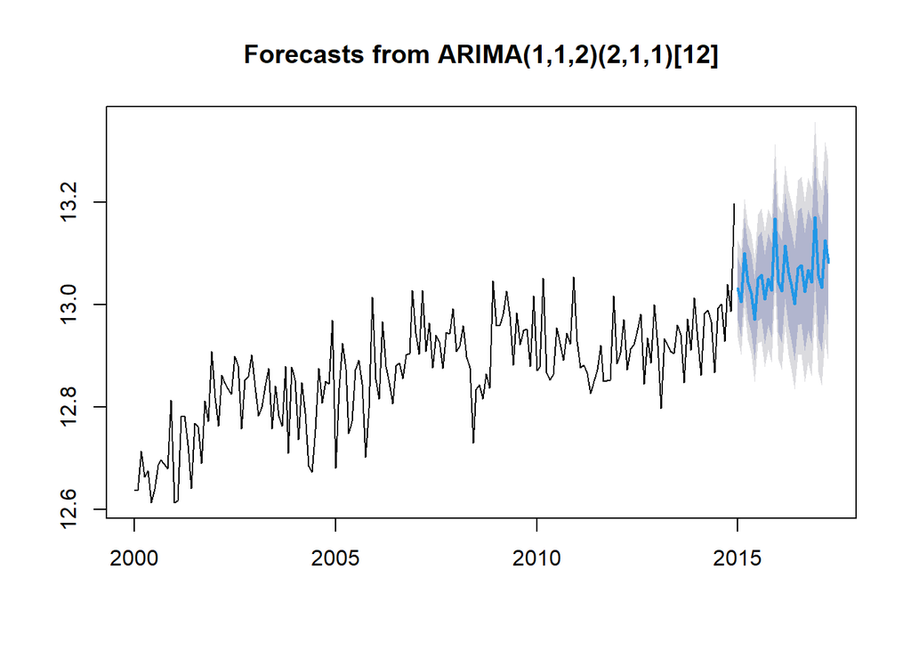

```r
plot(forecast(fitArima,h))
```

```r
df<-data.frame(ds=as.Date(as.yearmon(time(train))),y=as.matrix(train) )
testdf<-data.frame(ds=as.Date(as.yearmon(time(test))),y=as.matrix(test) )
fitProphet<-prophet(df,yearly.seasonality = T,weekly.seasonality = T)
```

```
## Disabling daily seasonality. Run prophet with daily.seasonality=TRUE to override this.
```

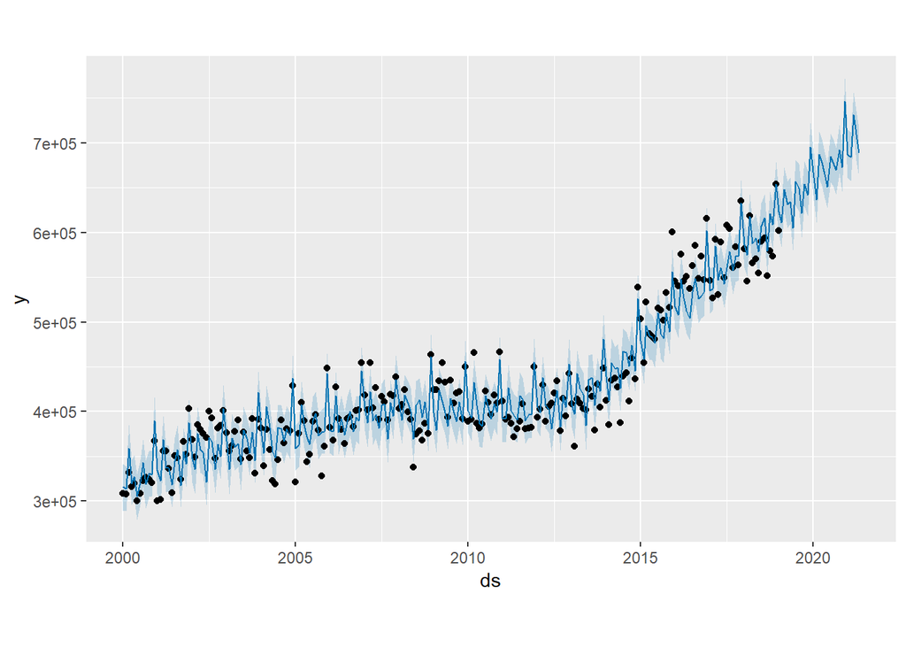

```r
future <- make_future_dataframe(fitProphet,periods = h,freq = "month", include_history = T)
p <- predict(fitProphet,future)
p<-p[,c("ds","yhat","yhat_lower","yhat_upper")]
plot(fitProphet,p)
```

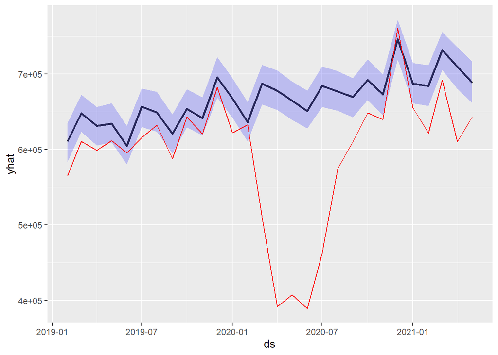

```r
pred<-tail(p,h)
pred$y<-testdf$y


ggplot(pred, aes(x=ds, y=yhat)) +
   geom_line(size=1, alpha=0.8) +
   geom_ribbon(aes(ymin=yhat_lower, ymax=yhat_upper), fill="blue", alpha=0.2) +
   geom_line(data=pred, aes(x=ds, y=y),color="red")
```

#### Serie de tiempo Gasolina Super Importacion

Union de columnas de tiempo

Creando la serie de tiempo. Viendo incio, fin y frencuencia

```
## [1] 2001    1
```

```
## [1] 2021    5
```

```
## [1] 12
```

Creando el grafico de la serie

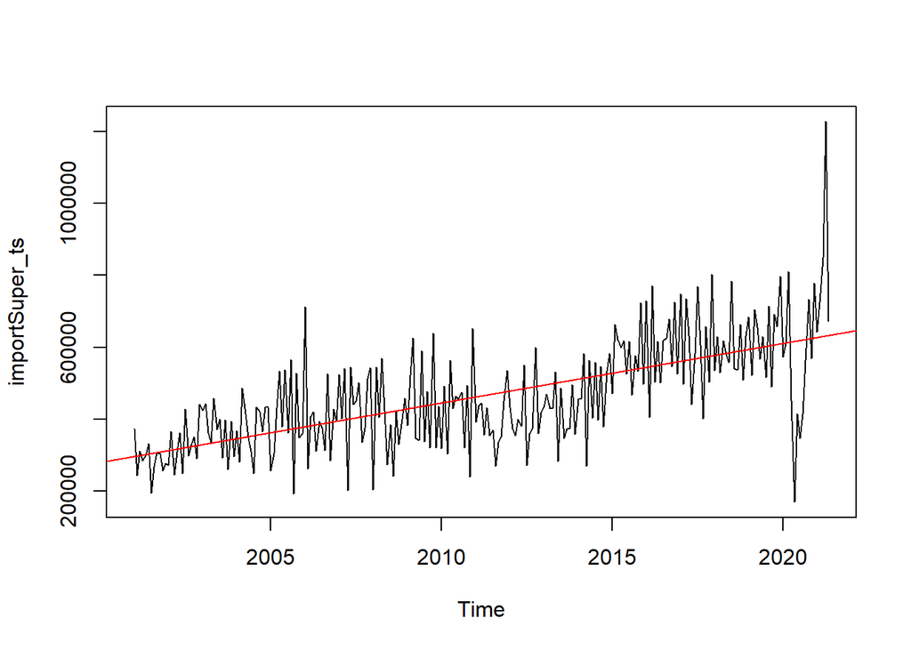

Se observa que es una serie de tiempo no estacionaria ya que su componente tendencia no es constante, si no que es creciente. Ademas, la varianza tampoco es constante.

Descomponiendo la serie

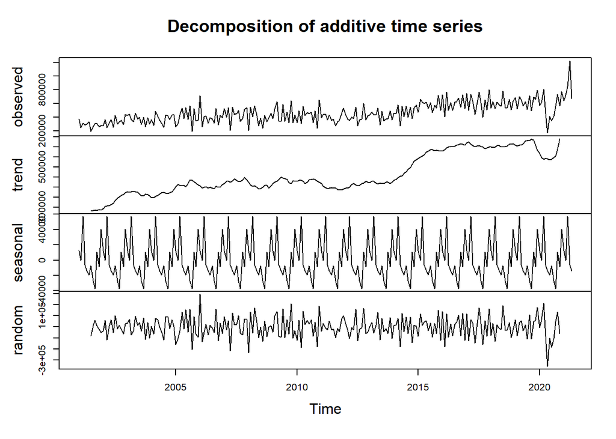

Se puede observar que la componente tendencia es creciente, la componente estacional si tiene un patron y la varianza no es constante. Se tendra que transformar

Transformacion logaritmica para estacionar serie

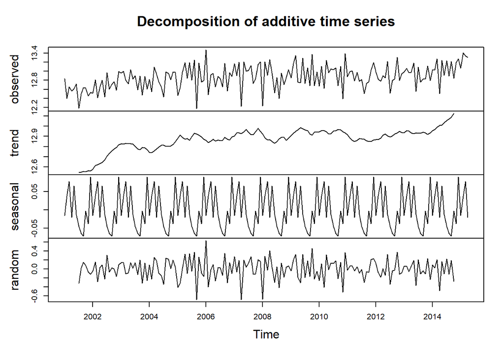

```r
logSS <- log(trainS)
lambda <- BoxCox.lambda(trainS)
boxcoxGR<-BoxCox(trainS,lambda)

plot(decompose(logSS))
```

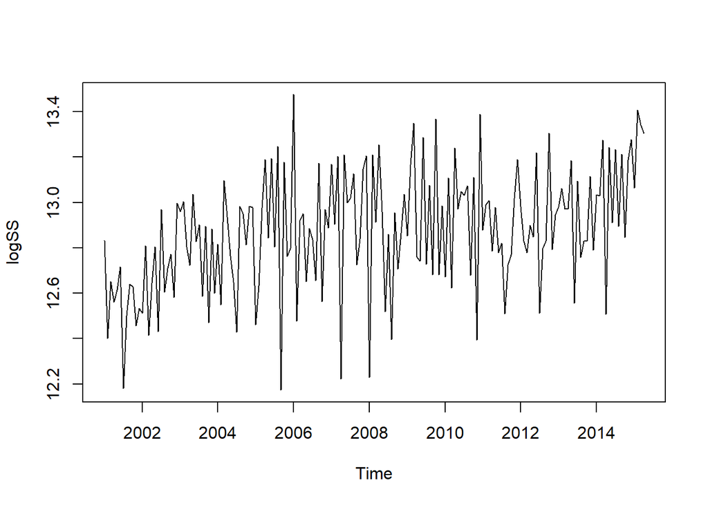

```r
plot(logSS)
```

Al hacer la transformacion logaritmica, se observa que la serie se ha estabilizado un poco mas en media. Sin embargo en varianza sigue lejos de estar constante

Ahora se haran las pruebas de DickeyFuller

```r
adfTest(trainS)
```

```
##
## Title:
##  Augmented Dickey-Fuller Test
##
## Test Results:
##   PARAMETER:
##     Lag Order: 1
##   STATISTIC:
##     Dickey-Fuller: -0.567
##   P VALUE:
##     0.4339
##
## Description:
##  Fri Aug 06 20:30:01 2021 by user: LUIS PEDRO
```

```r
unitrootTest(trainS)
```

```
##
## Title:
##  Augmented Dickey-Fuller Test
##
## Test Results:
##   PARAMETER:
##     Lag Order: 1
##   STATISTIC:
##     DF: -0.567
##   P VALUE:
##     t: 0.4704
##     n: 0.5542
##
## Description:
##  Fri Aug 06 20:30:01 2021 by user: LUIS PEDRO
```

Con las pruebas de Dickey-Fuller, se observa que p es mayor a 0.05. No se puede rechazar Ho y existen raices unitarias. Aunque la serie se vea mas estable en media, aun no es estacionaria en media

Ahora se hace con una diferenciacion en la serie de tiempo

```r
GS_diff<-diff(logSS)
adfTest(diff(trainS))
```

```
##
## Title:
##  Augmented Dickey-Fuller Test
##
## Test Results:
##   PARAMETER:
##     Lag Order: 1
##   STATISTIC:
##     Dickey-Fuller: -16.9539
##   P VALUE:
##     0.01
##
## Description:
##  Fri Aug 06 20:30:01 2021 by user: LUIS PEDRO
```

Ahora el valor p si es menor a 0.05. Ahora si se puede rechazar la Ho, y ahora no hay raices unitarias

Valores de p y q

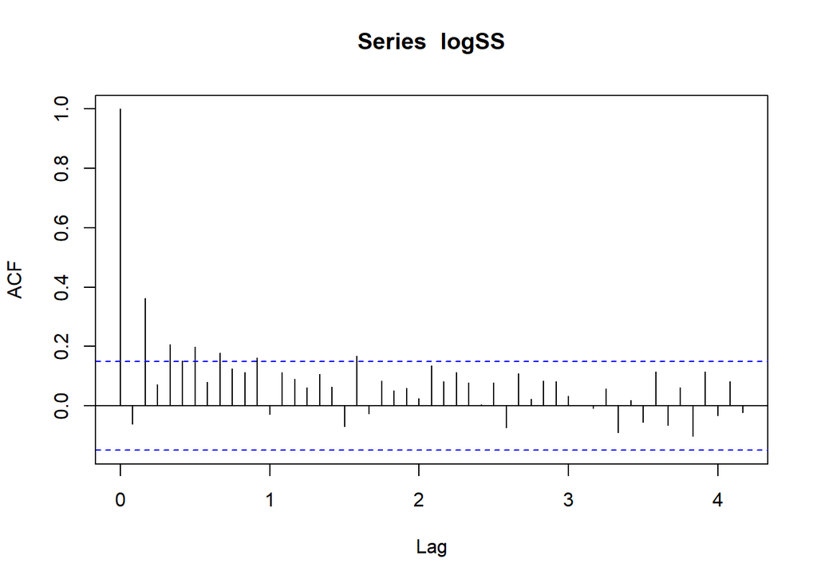

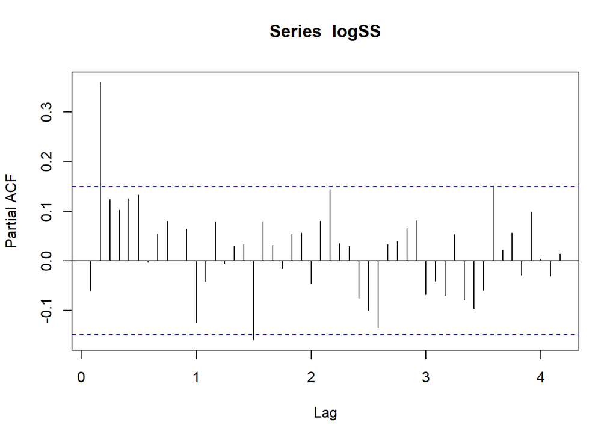

Valores p y q del la componente estacional

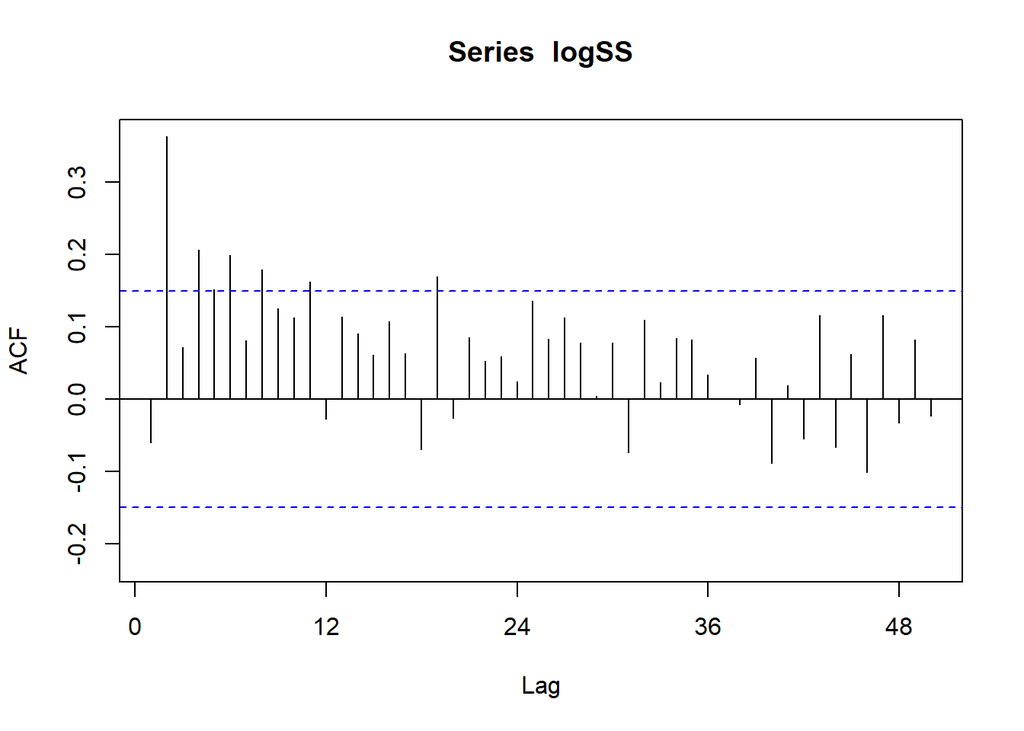

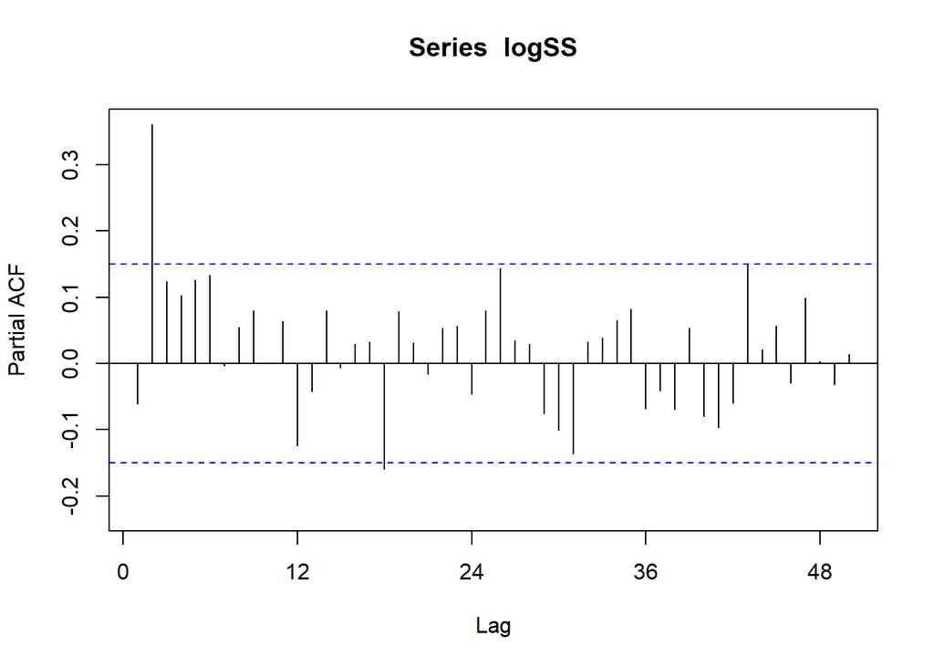

p es 1 ya que se tiene solamente un ciclo antes de que se anule q es 1 ya que se acerca a la frecuencia de 12, antes de anularse Por lo tanto, tenemos un modelo ARIMA (1,1,1)

Ahora se comprobara mediante fitarima si en efecto, los coeficiente son significativos

```
##
## z test of coefficients:
##
##       Estimate Std. Error  z value  Pr(>|z|)
## ar1  -0.418542   0.077040  -5.4328 5.549e-08 ***
## ma1  -0.856811   0.045973 -18.6372 < 2.2e-16 ***
## sar1 -0.197184   0.080253  -2.4570   0.01401 *
## sma1 -0.999990   0.099506 -10.0495 < 2.2e-16 ***
## ---
## Signif. codes:  0 '***' 0.001 '**' 0.01 '*' 0.05 '.' 0.1 ' ' 1
```

```
##
## z test of coefficients:
##
##          Estimate  Std. Error z value  Pr(>|z|)
## ar1     -0.654059    0.148938 -4.3915 1.126e-05 ***
## ma1     -0.537645    0.181707 -2.9589  0.003088 **
## ma2     -0.299850    0.177230 -1.6919  0.090670 .
## sma1    -0.161559    0.081102 -1.9921  0.046365 *
## drift 1299.928853  616.505243  2.1085  0.034984 *
## ---
## Signif. codes:  0 '***' 0.001 '**' 0.01 '*' 0.05 '.' 0.1 ' ' 1
```

Ahora se hace el analisis de los residuales

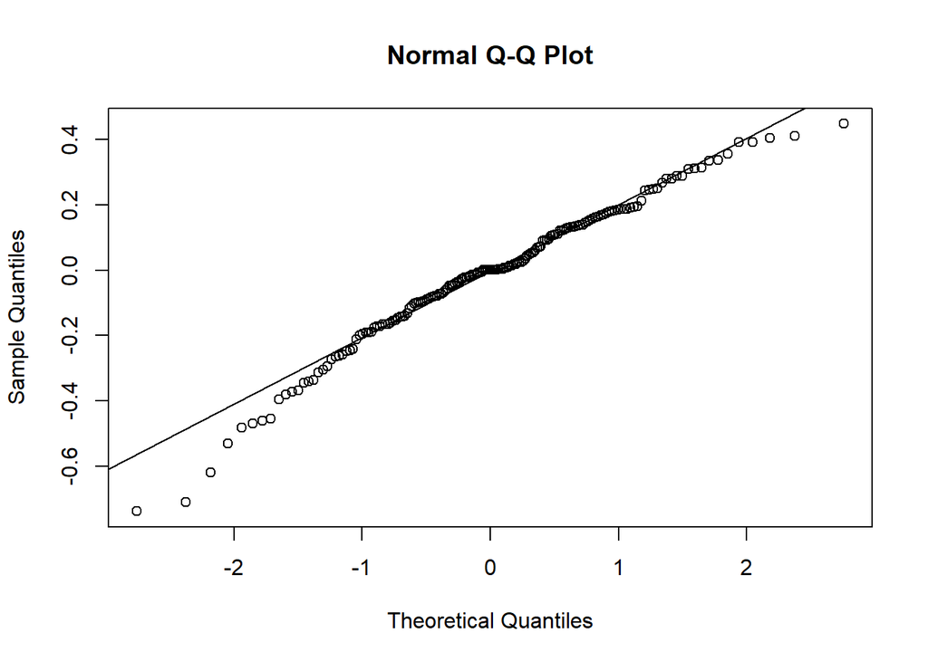

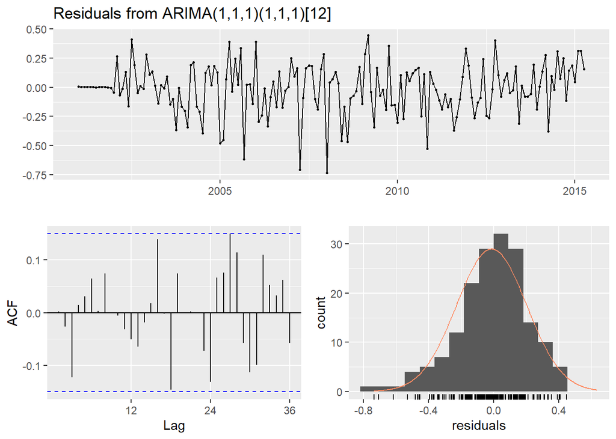

```
##
##  Ljung-Box test
##
## data:  Residuals from ARIMA(1,1,1)(1,1,1)[12]
## Q* = 19.747, df = 20, p-value = 0.4738
##
## Model df: 4.   Total lags used: 24
```

Los residuos se comportan de manera normal y continua. Ademas, en la prueba L-jung-Box se tuvo un valor de p mayor a 0.05. Por lo que es un modelo apto para predecir.

Ahora se hace la prediccion arima en si.

```
##          Point Forecast    Lo 80    Hi 80    Lo 95    Hi 95
## May 2015       13.15250 12.85453 13.45046 12.69680 13.60819
## Jun 2015       13.19007 12.88110 13.49905 12.71754 13.66261
## Jul 2015       13.05966 12.74122 13.37810 12.57264 13.54667
## Aug 2015       13.11468 12.79608 13.43328 12.62742 13.60194
## Sep 2015       13.04087 12.71997 13.36177 12.55010 13.53165
## Oct 2015       13.20716 12.88517 13.52914 12.71472 13.69959
## Nov 2015       13.10977 12.78623 13.43331 12.61496 13.60458
## Dec 2015       13.23458 12.90986 13.55929 12.73797 13.73118
## Jan 2016       13.17263 12.84683 13.49842 12.67437 13.67089
## Feb 2016       13.15992 12.83276 13.48709 12.65957 13.66028
## Mar 2016       13.23094 12.90240 13.55948 12.72848 13.73340
## Apr 2016       13.12845 12.79855 13.45836 12.62391 13.63300
## May 2016       13.24550 12.91553 13.57546 12.74086 13.75013
## Jun 2016       13.17113 12.83867 13.50360 12.66267 13.67960
## Jul 2016       13.14640 12.81334 13.47947 12.63702 13.65578
## Aug 2016       13.11720 12.78290 13.45149 12.60594 13.62846
## Sep 2016       13.12343 12.78819 13.45866 12.61073 13.63613
## Oct 2016       13.18349 12.84722 13.51976 12.66921 13.69777
## Nov 2016       13.17294 12.83565 13.51024 12.65709 13.68879
## Dec 2016       13.29044 12.95228 13.62861 12.77326 13.80762
## Jan 2017       13.19911 12.86005 13.53818 12.68056 13.71766
## Feb 2017       13.25628 12.91622 13.59633 12.73621 13.77635
## Mar 2017       13.30061 12.95957 13.64165 12.77904 13.82219
## Apr 2017       13.21080 12.86878 13.55283 12.68772 13.73388
## May 2017       13.27490 12.92861 13.62119 12.74530 13.80451
## Jun 2017       13.22261 12.87586 13.56936 12.69230 13.75292
## Jul 2017       13.17704 12.82870 13.52538 12.64430 13.70978
## Aug 2017       13.16445 12.81507 13.51382 12.63013 13.69877
## Sep 2017       13.15489 12.80426 13.50552 12.61865 13.69113
## Oct 2017       13.23590 12.88414 13.58766 12.69793 13.77386
## Nov 2017       13.20823 12.85524 13.56121 12.66839 13.74807
## Dec 2017       13.32717 12.97320 13.68114 12.78582 13.86852
## Jan 2018       13.24163 12.88654 13.59673 12.69856 13.78471
## Feb 2018       13.28502 12.92878 13.64126 12.74020 13.82984
## Mar 2018       13.33462 12.97724 13.69200 12.78806 13.88118
## Apr 2018       13.24231 12.88380 13.60082 12.69401 13.79060
## May 2018       13.31685 12.95568 13.67801 12.76449 13.86920
## Jun 2018       13.26020 12.89823 13.62217 12.70662 13.81379
## Jul 2018       13.21874 12.85532 13.58216 12.66294 13.77455
```

[output cut: 19 more lines]

```
## Mar 2020       13.41531 13.02572 13.80490 12.81948 14.01114
## Apr 2020       13.32339 12.93257 13.71422 12.72568 13.92111
## May 2020       13.39628 13.00244 13.79013 12.79395 13.99861
## Jun 2020       13.34033 12.94563 13.73502 12.73670 13.94396
## Jul 2020       13.29821 12.90192 13.69451 12.69213 13.90430
## Aug 2020       13.28286 12.88532 13.68041 12.67487 13.89086
## Sep 2020       13.27593 12.87697 13.67488 12.66578 13.88608
## Oct 2020       13.35346 12.95321 13.75370 12.74134 13.96558
## Nov 2020       13.32863 12.92696 13.73030 12.71433 13.94293
## Dec 2020       13.44733 13.04458 13.85008 12.83138 14.06329
## Jan 2021       13.36084 12.95657 13.76511 12.74256 13.97911
## Feb 2021       13.40651 13.00096 13.81207 12.78627 14.02675
## Mar 2021       13.45523 13.04840 13.86207 12.83303 14.07744
## Apr 2021       13.36334 12.95522 13.77145 12.73918 13.98749
## May 2021       13.43615 13.02495 13.84734 12.80728 14.06501
```

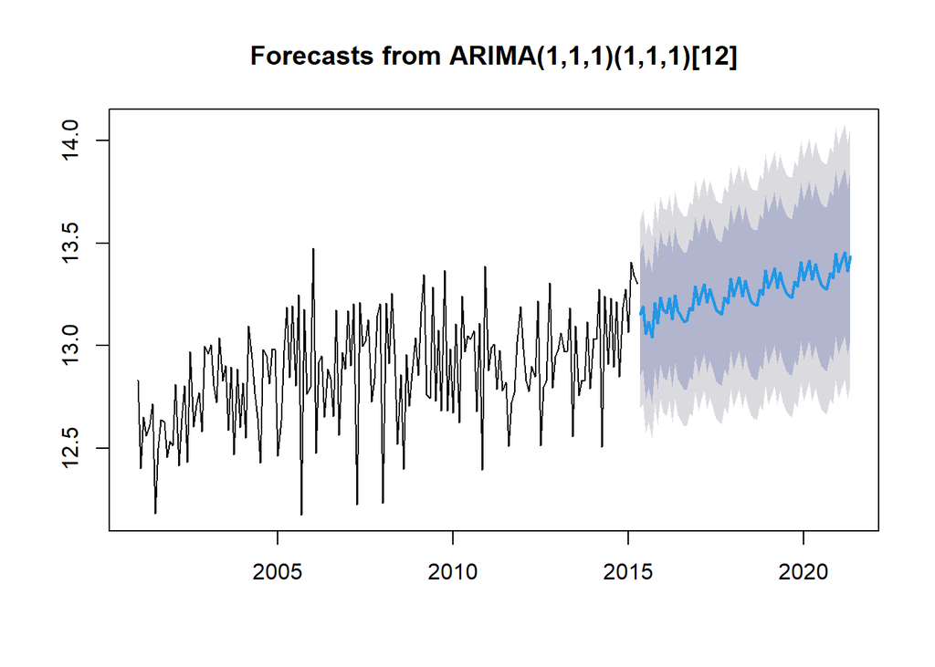

Se puede observar que el algoritmo pudo predecir la tendencia, sin embargo, no pudo predecir los datos.

#### Analisis con profet de facebook gasolina super importacion

[output not shown]

[output cut: 330 more lines]

[output not shown]

```
## Disabling daily seasonality. Run prophet with daily.seasonality=TRUE to override this.
```

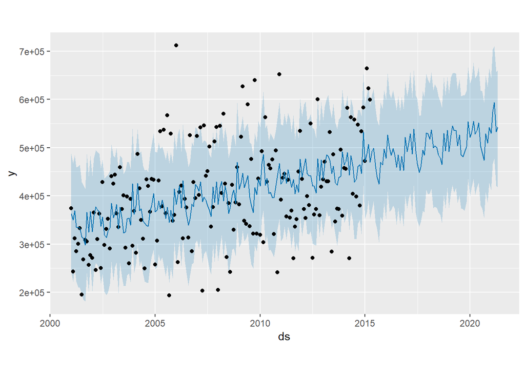

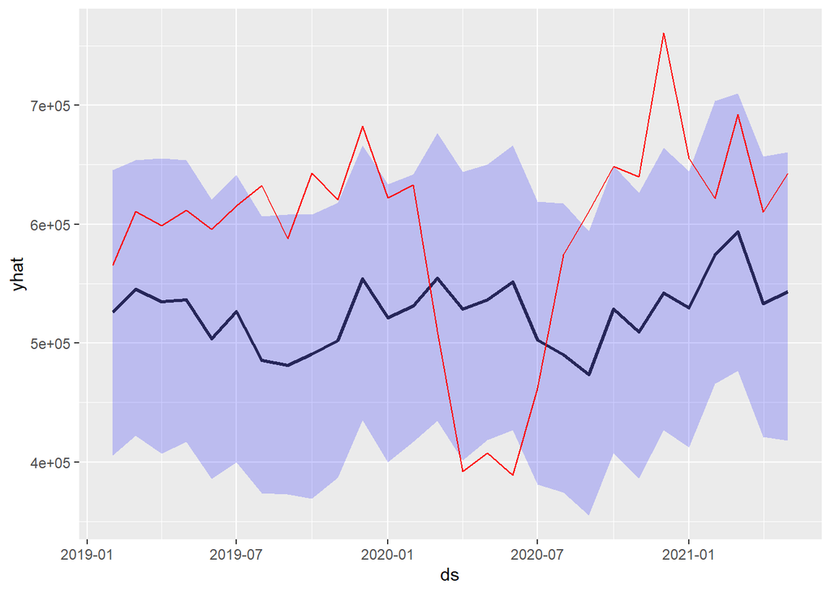

```r
pred<-tail(p,h)
pred$y<-testdf$y


ggplot(pred, aes(x=ds, y=yhat)) +
   geom_line(size=1, alpha=0.8) +
   geom_ribbon(aes(ymin=yhat_lower, ymax=yhat_upper), fill="blue", alpha=0.2) +
   geom_line(data=pred, aes(x=ds, y=y),color="red")
```

Como se puede observar, el ARIMA tuvo una mejor prediccion.

```r
train <- head(importSuper_ts, round(length(importSuper_ts) * 0.891632653))
h <- length(importSuper_ts) - length(train)
test <- tail(importSuper_ts, h)
end(train)
```

```
## [1] 2019    2
```

```r
fitArima %>%
  forecast(h)
```

```
##          Point Forecast    Lo 80    Hi 80    Lo 95    Hi 95
## May 2015       13.15250 12.85453 13.45046 12.69680 13.60819
## Jun 2015       13.19007 12.88110 13.49905 12.71754 13.66261
## Jul 2015       13.05966 12.74122 13.37810 12.57264 13.54667
## Aug 2015       13.11468 12.79608 13.43328 12.62742 13.60194
## Sep 2015       13.04087 12.71997 13.36177 12.55010 13.53165
## Oct 2015       13.20716 12.88517 13.52914 12.71472 13.69959
## Nov 2015       13.10977 12.78623 13.43331 12.61496 13.60458
## Dec 2015       13.23458 12.90986 13.55929 12.73797 13.73118
## Jan 2016       13.17263 12.84683 13.49842 12.67437 13.67089
## Feb 2016       13.15992 12.83276 13.48709 12.65957 13.66028
## Mar 2016       13.23094 12.90240 13.55948 12.72848 13.73340
## Apr 2016       13.12845 12.79855 13.45836 12.62391 13.63300
## May 2016       13.24550 12.91553 13.57546 12.74086 13.75013
## Jun 2016       13.17113 12.83867 13.50360 12.66267 13.67960
## Jul 2016       13.14640 12.81334 13.47947 12.63702 13.65578
## Aug 2016       13.11720 12.78290 13.45149 12.60594 13.62846
## Sep 2016       13.12343 12.78819 13.45866 12.61073 13.63613
## Oct 2016       13.18349 12.84722 13.51976 12.66921 13.69777
## Nov 2016       13.17294 12.83565 13.51024 12.65709 13.68879
## Dec 2016       13.29044 12.95228 13.62861 12.77326 13.80762
## Jan 2017       13.19911 12.86005 13.53818 12.68056 13.71766
## Feb 2017       13.25628 12.91622 13.59633 12.73621 13.77635
## Mar 2017       13.30061 12.95957 13.64165 12.77904 13.82219
## Apr 2017       13.21080 12.86878 13.55283 12.68772 13.73388
## May 2017       13.27490 12.92861 13.62119 12.74530 13.80451
## Jun 2017       13.22261 12.87586 13.56936 12.69230 13.75292
## Jul 2017       13.17704 12.82870 13.52538 12.64430 13.70978
```

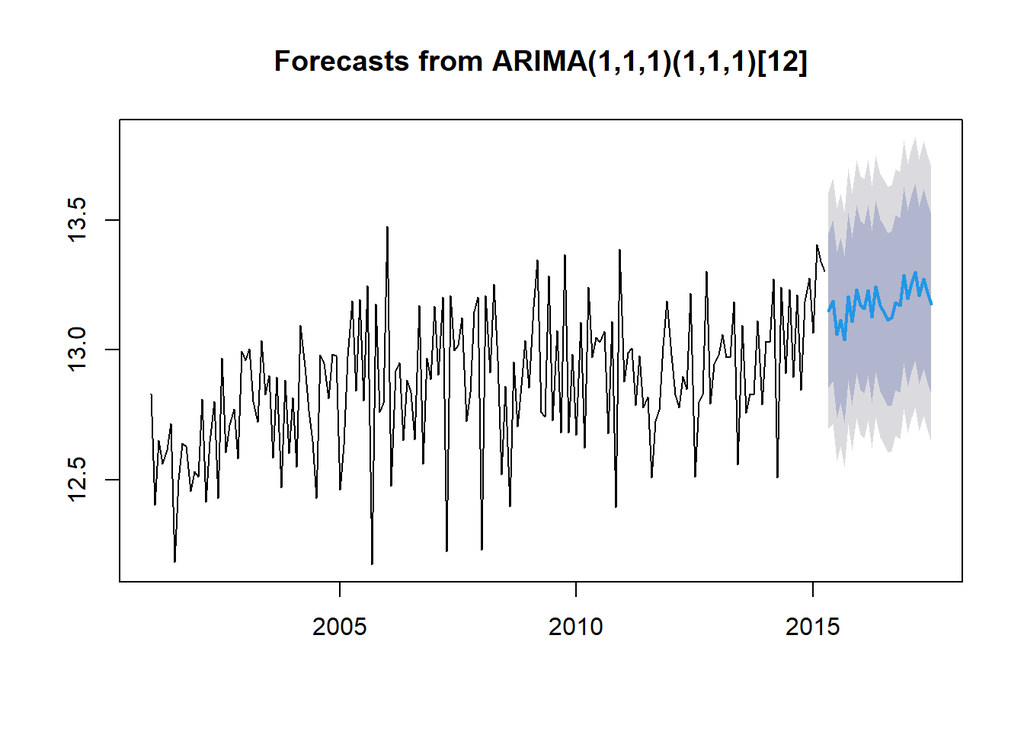

```r
plot(forecast(fitArima,h))
```

```r
df<-data.frame(ds=as.Date(as.yearmon(time(train))),y=as.matrix(train) )
testdf<-data.frame(ds=as.Date(as.yearmon(time(test))),y=as.matrix(test) )
fitProphet<-prophet(df,yearly.seasonality = T,weekly.seasonality = T)
```

```
## Disabling daily seasonality. Run prophet with daily.seasonality=TRUE to override this.
```

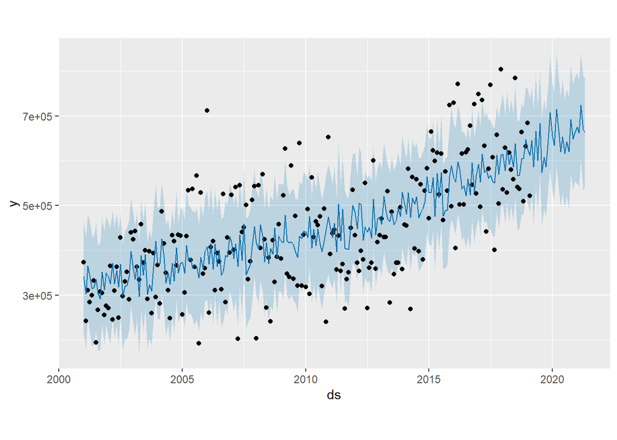

```r
future <- make_future_dataframe(fitProphet,periods = h,freq = "month", include_history = T)
p <- predict(fitProphet,future)
p<-p[,c("ds","yhat","yhat_lower","yhat_upper")]
plot(fitProphet,p)
```

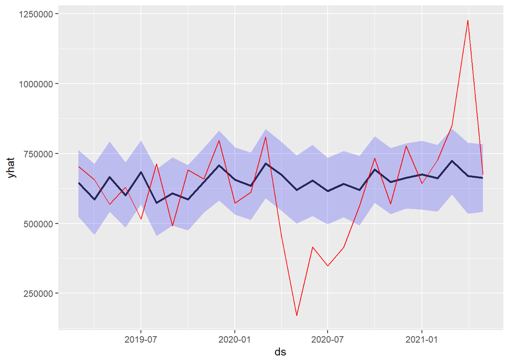

```r
pred<-tail(p,h)
pred$y<-testdf$y


ggplot(pred, aes(x=ds, y=yhat)) +
   geom_line(size=1, alpha=0.8) +
   geom_ribbon(aes(ymin=yhat_lower, ymax=yhat_upper), fill="blue", alpha=0.2) +
   geom_line(data=pred, aes(x=ds, y=y),color="red")
```

```r
consumoGR_ts <- xts(consumoRegular$cantRegular, consumoRegular$regularDate)
consumoGR_ts <-ts_ts(consumoGR_ts)
#Saber cuando empieza la serie y cuando termina
start(consumoGR_ts)
```

```
## [1] 2000    1
```

```r
end(consumoGR_ts)
```

```
## [1] 2021    5
```

```r
#Saber la frecuencia de la serie
frequency(consumoGR_ts)
```

```
## [1] 12
```

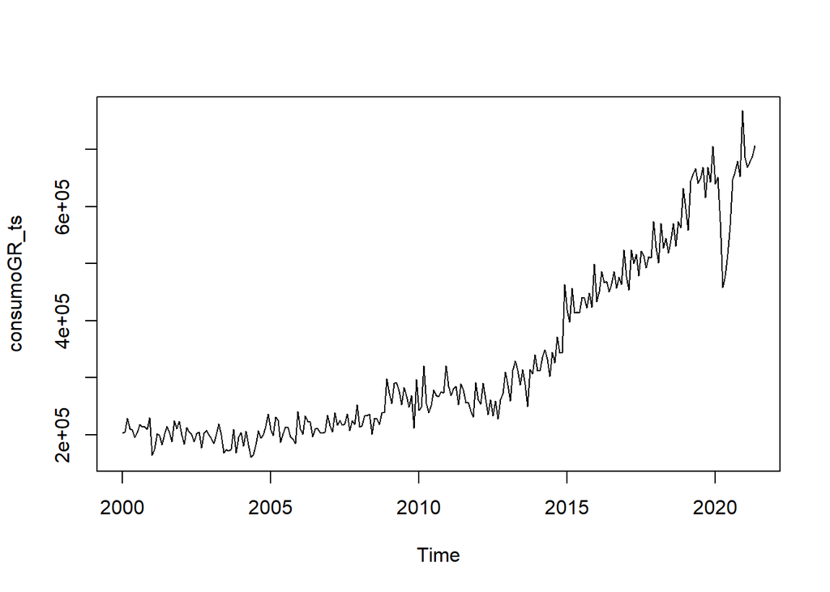

```r
#Ver el grÃ¡fico de la serie
plot(consumoGR_ts)
```

```r
###Analisis Importacion Gasolina Regular y Diesel
datosImport <- read.csv(file = 'DatosImportacionCombustibles.csv')

datosImport$Dia <- 1
datosImport$Date <- as.Date(with(datosImport, paste(Anio, Mes, Dia,sep="-")), "%Y-%m-%d")

cantRegular <- c(datosImport$GasolinaRegular)
regularDate <- c(datosImport$Date)
importRegular <- data.frame(cantRegular,regularDate)

cantDiesel <- c(datosImport$TotalDiesel)
dieselDate <- c(datosImport$Date)
importDiesel <- data.frame(cantDiesel,dieselDate)
```

Inicio y fin de la importacion Gasolina Regular

```r
importRegular_ts <- xts(importRegular$cantRegular, importRegular$regularDate)
importRegular_ts <-ts_ts(importRegular_ts)

start(importRegular_ts)
```

```
## [1] 2001    1
```

```r
end(importRegular_ts)
```

```
## [1] 2021    5
```

```r
train <- head(importRegular_ts, round(length(importRegular_ts) * 0.7))
h <- length(importRegular_ts) - length(train)
test <- tail(importRegular_ts, h)
```

Frecuencia serie importacion Gasolina Regular

```r
frequency(importRegular_ts)
```

```
## [1] 12
```

Grafico de la serie importacion Gasolina Regular

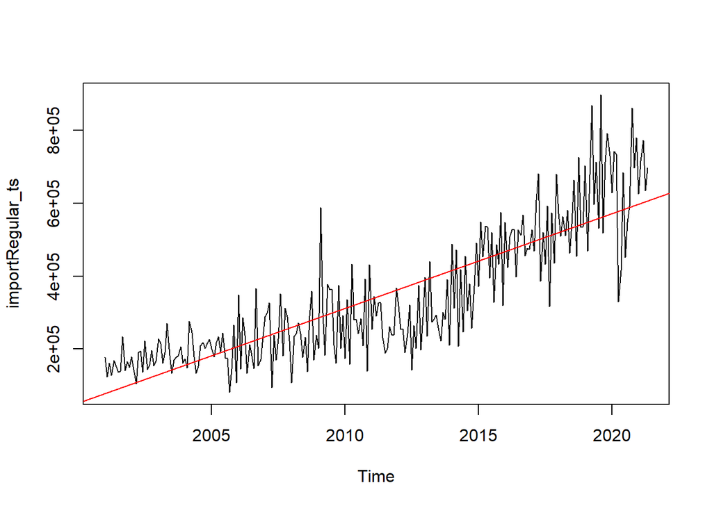

```r
plot(importRegular_ts)
abline(reg=lm(importRegular_ts~time(importRegular_ts)), col=c("red"))
```

De la grafica puedo observar que tiene tendencia a aumentar. No es estacionaria media

Descomposicion serie importacion Gasolina Regular

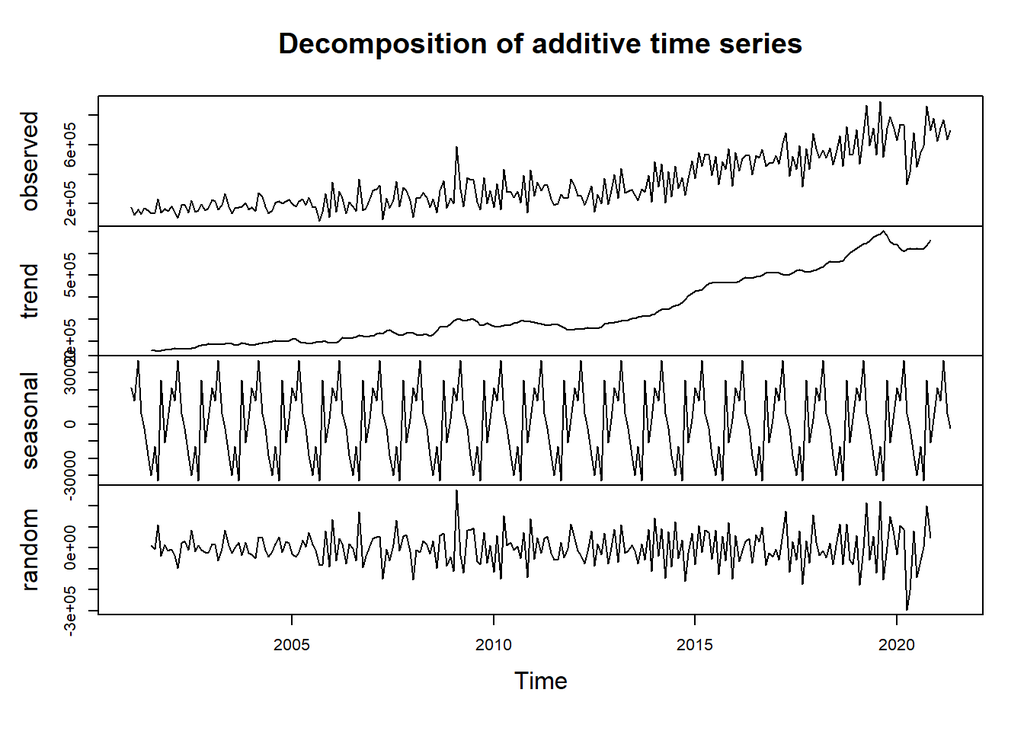

```r
dec.GS<-decompose(importRegular_ts)
plot(dec.GS)
```

Por la descomposicion tampoco parece ser estacionaria en varianza. El factor aleatorio parece tener un patron por lo que no sera una serie util para predecir. Es necesario transformarla

Transformacion log y grafico autocorrelacion serie importacion Gasolina Regular

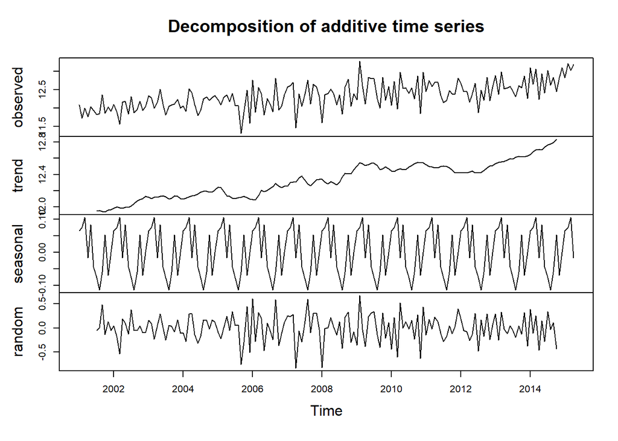

```r
logIR <- log(train)
lambda <- BoxCox.lambda(train)
boxcoxGR<-BoxCox(train,lambda)

plot(decompose(logIR))
```

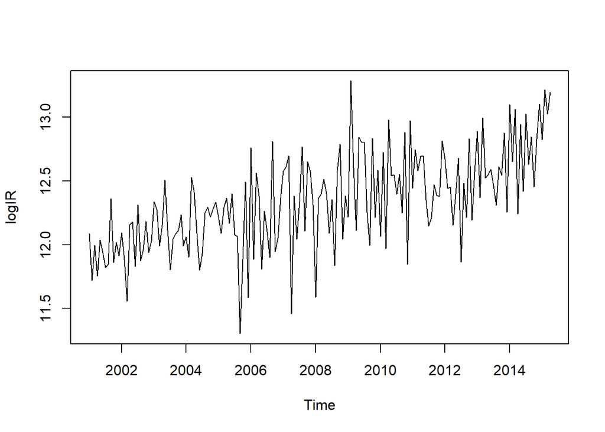

```r
plot(logIR)
```

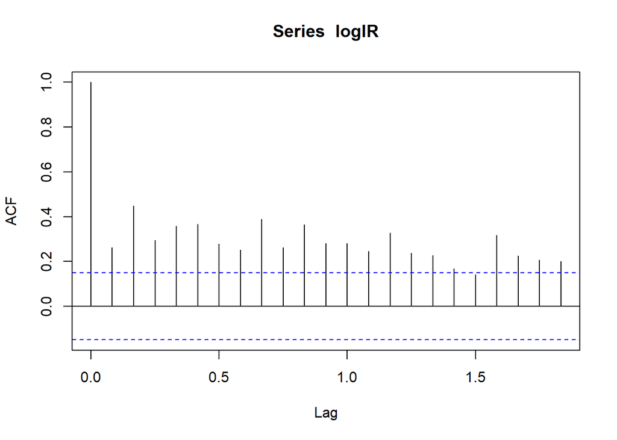

```r
acf(logIR)
```

No hay estacionariedad media

Prueba Dickey-Fuller

```r
adfTest(train)
```

```
##
## Title:
##  Augmented Dickey-Fuller Test
##
## Test Results:
##   PARAMETER:
##     Lag Order: 1
##   STATISTIC:
##     Dickey-Fuller: -0.6179
##   P VALUE:
##     0.4177
##
## Description:
##  Fri Aug 06 20:30:07 2021 by user: LUIS PEDRO
```

```r
unitrootTest(train)
```

```
##
## Title:
##  Augmented Dickey-Fuller Test
##
## Test Results:
##   PARAMETER:
##     Lag Order: 1
##   STATISTIC:
##     DF: -0.6179
##   P VALUE:
##     t: 0.4484
##     n: 0.5437
##
## Description:
##  Fri Aug 06 20:30:07 2021 by user: LUIS PEDRO
```

El test Dickey-Fuller resulta con valores mayores a 0.05 por lo que Ho no se rechaza. Si hay raices unitarias. Se debe hacer una diferenciacion de la serie de tiempo.

Diferenciacion serie importacion Gasolina Regular

```r
IR_diff<-diff(logIR)
adfTest(diff(train))
```

```
##
## Title:
##  Augmented Dickey-Fuller Test
##
## Test Results:
##   PARAMETER:
##     Lag Order: 1
##   STATISTIC:
##     Dickey-Fuller: -15.4037
##   P VALUE:
##     0.01
##
## Description:
##  Fri Aug 06 20:30:07 2021 by user: LUIS PEDRO
```

Al hacer este cambio el valor p si es menor a 0.05, se rechaza Ho y ahora no hay raices unitarias

Valores p y q

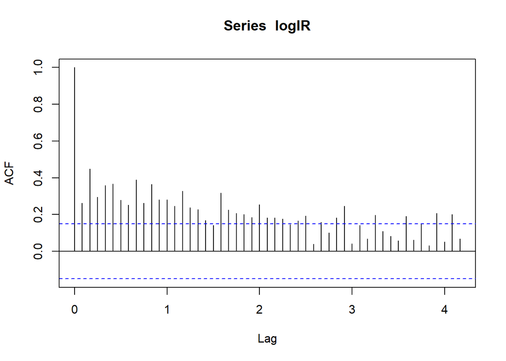

```r
acf(logIR,50)
```

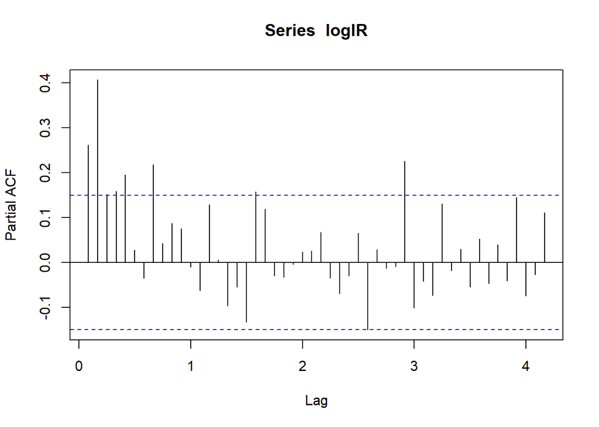

```r
pacf(logIR,50)
```

Inicio y fin de la importacion Gasolina Diesel

```r
importDiesel_ts <- xts(importDiesel$cantDiesel, importDiesel$dieselDate)
importDiesel_ts <-ts_ts(importDiesel_ts)

start(importDiesel_ts)
```

```
## [1] 2001    1
```

```r
end(importDiesel_ts)
```

```
## [1] 2021    5
```

```r
train <- head(importDiesel_ts, round(length(importDiesel_ts) * 0.7))
h <- length(importDiesel_ts) - length(train)
test <- tail(importDiesel_ts, h)
```

Frecuencia serie importacion Gasolina Diesel

```r
frequency(importDiesel_ts)
```

```
## [1] 12
```

Grafico de la serie importacion Gasolina Diesel

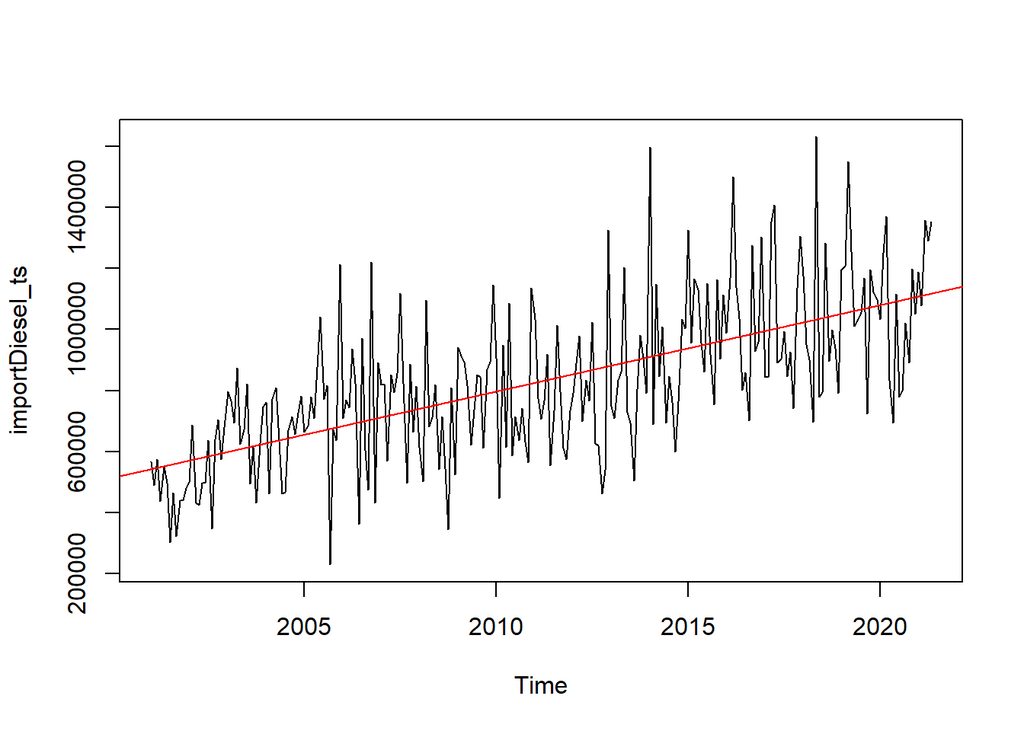

```r
plot(importDiesel_ts)
abline(reg=lm(importDiesel_ts~time(importDiesel_ts)), col=c("red"))
```

De la grafica puedo observar que tiene tendencia a aumentar. No es estacionaria media

Descomposicion serie importacion Gasolina Diesel

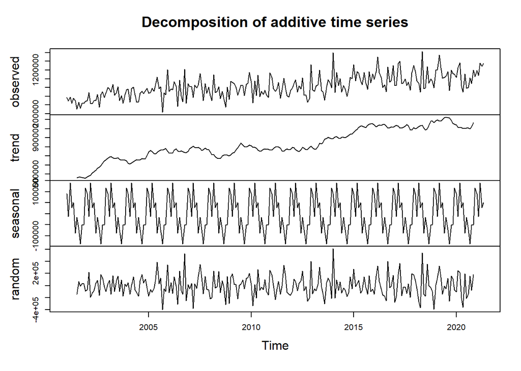

```r
dec.GD<-decompose(importDiesel_ts)
plot(dec.GD)
```

Por la descomposicion tampoco parece ser estacionaria en varianza. El factor aleatorio parece tener un patron por lo que no sera una serie util para predecir. Es necesario transformarla

Transformacion log y grafico autocorrelacion serie importacion Gasolina Diesel

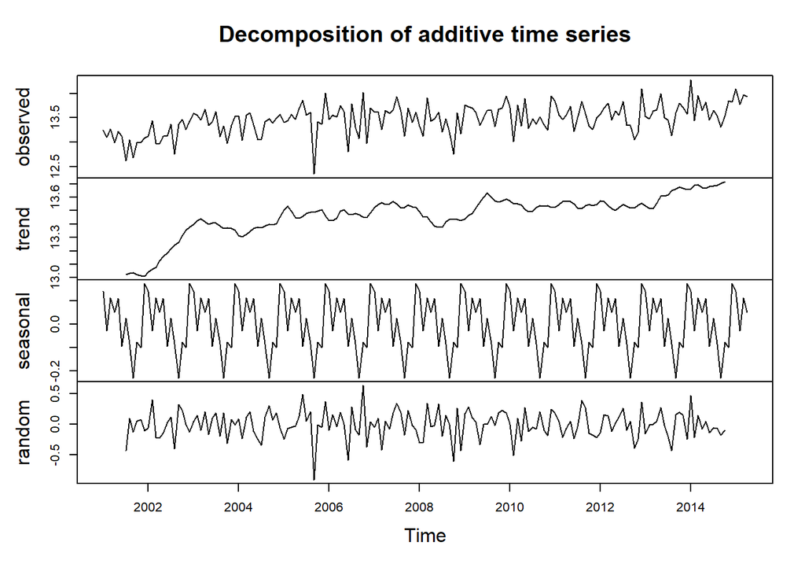

```r
logID <- log(train)
lambda <- BoxCox.lambda(train)
boxcoxGD<-BoxCox(train,lambda)

plot(decompose(logID))
```

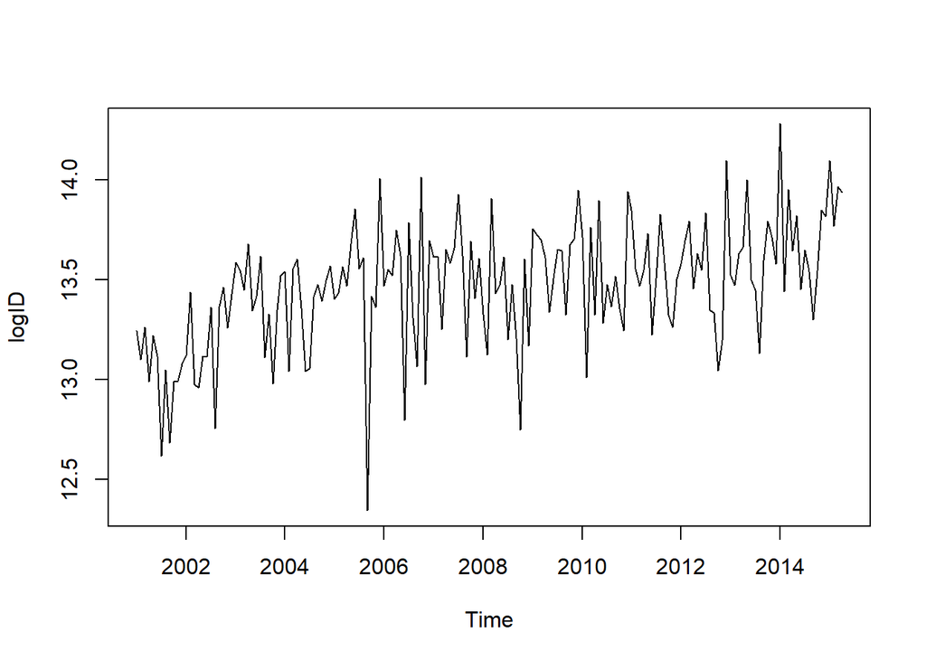

```r
plot(logID)
```

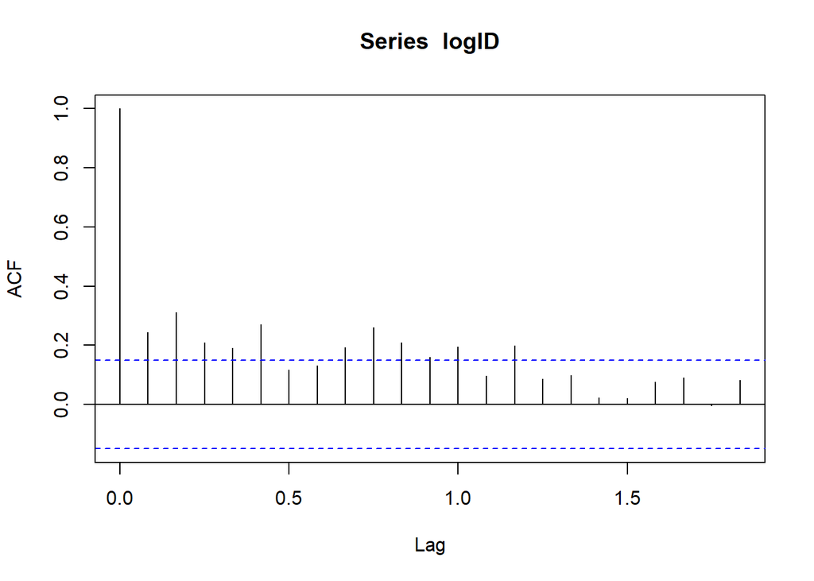

```r
acf(logID)
```

No hay estacionariedad media

Prueba Dickey-Fuller

```r
adfTest(train)
```

```
##
## Title:
##  Augmented Dickey-Fuller Test
##
## Test Results:
##   PARAMETER:
##     Lag Order: 1
##   STATISTIC:
##     Dickey-Fuller: -0.9005
##   P VALUE:
##     0.3276
##
## Description:
##  Fri Aug 06 20:30:08 2021 by user: LUIS PEDRO
```

```r
unitrootTest(train)
```

```
##
## Title:
##  Augmented Dickey-Fuller Test
##
## Test Results:
##   PARAMETER:
##     Lag Order: 1
##   STATISTIC:
##     DF: -0.9005
##   P VALUE:
##     t: 0.3248
##     n: 0.4892
##
## Description:
##  Fri Aug 06 20:30:08 2021 by user: LUIS PEDRO
```

Diferenciacion serie importacion Gasolina Diesel

```r
ID_diff<-diff(logID)
adfTest(diff(train))
```

```
##
## Title:
##  Augmented Dickey-Fuller Test
##
## Test Results:
##   PARAMETER:
##     Lag Order: 1
##   STATISTIC:
##     Dickey-Fuller: -15.2594
##   P VALUE:
##     0.01
##
## Description:
##  Fri Aug 06 20:30:08 2021 by user: LUIS PEDRO
```

Valores p y q

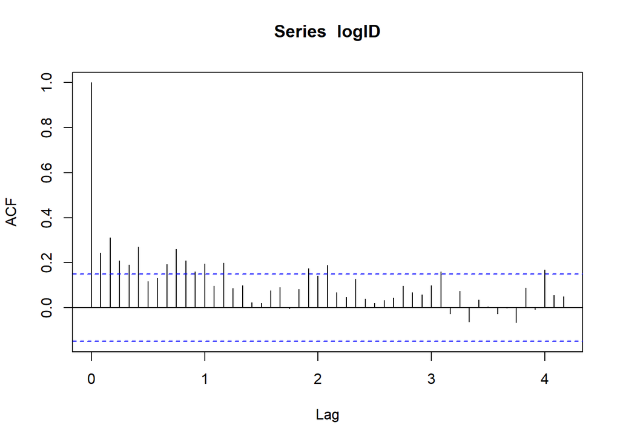

```r
acf(logID,50)
```

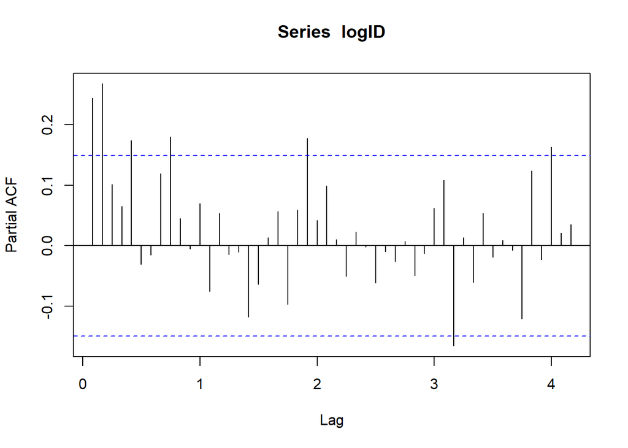

```r
pacf(logID,50)
```